# Data Science Project - Breast Cancer Survival with SEER data

KoohPy <- Koohyar Pooladvand

2024-05-12

### Data Preparation

In this project, I have chosen to work on **breast cancer**. There are various resources available on this topic, with the [**Surveillance, Epidemiology, and End Results (SEER)**](https://seer.cancer.gov/data/access.html) [1] program being the most reliable one.

The **SEER Program** of the National Cancer Institute (NCI) collects and publishes cancer data through a coordinated system of strategically placed cancer registries, covering nearly 30% of the US population.

Currently, there are **18 SEER registries** in the USA. You can find this information on the following website: SEER Data Access.

I have also utilized the following repository to assist me with this project: SEER_solid_tumor [2]. The database contains extensive data, and my investigation will focus solely on **breast cancer** for the years 2011-2015 and 2019-2020. SEER provides a software called **STAT** that I’ve used to import the data, which is stored and utilized on my local computer. Additionally, there are two GitHub repositories that I’ve referenced to some extent in this project:

1. The [first](https://github.com/zgalochkina/SEER_solid_tumor) [2]repository covers all types of cancer, but my study specifically focuses on **breast cancer**, addressing different research questions.
2. The [second](https://github.com/CarlosHernandezP/xai-healthcare/tree/master) [3] repository has conducted machine learning analyses on various cancer types using Python (not R). I’ve drawn inspiration and learned methods from their approach to survival studies in cancer patients.

## R initialization

Checking all the packages are installed and if not install as needed.

### Research question

The primary focus of my research is to explore the survival rates of breast cancer patients and the various factors influencing these rates, including age, cancer type, treatment modalities, and other pertinent parameters. The commonly utilized five-year survival rate benchmark serves as a pivotal point of analysis in this study.

Although my research is not conducted within a strictly scientific framework, it is approached with rigor and attention to detail. While I do not possess expertise in the field of breast cancer, my personal connection to the topic motivates me to delve deeper into understanding the complexities surrounding it.

The dataset from 2011 to 2015 comprises approximately 303,000 rows with 36 selected columns. For the purpose of prediction, I have chosen to focus solely on the 2019-2020 data, which encompasses about 131,000 rows. The multifaceted nature of the research question necessitates a thorough examination, from data tidying to cleaning.

Some of the key parameters under consideration include years of diagnoses, age groups at diagnosis, and cancer type. However, I also recognize the importance of incorporating additional factors such as tumor characteristics and treatment modalities to provide a comprehensive understanding of breast cancer survival outcomes.

In conclusion, while my knowledge of the subject may not be extensive, I am committed to learning and contributing meaningful insights to the field of breast cancer research through meticulous analysis and interpretation of data.

### Note on 5 years threshold

According to the American Cancer Society, the five-year relative survival rate for localized breast cancer is around 99%, but it drops to about 27% for distant-stage breast cancer. These rates can vary over time and with advances in treatment. Reference [5]: American Cancer Society - Breast Cancer Survival Rates

```r
# Function to load CSV file
load_csv <- function(file_path) {
  if (file.exists(file_path)) {
    return(read_csv(file_path))
  } else {
    message("File not found locally. Attempting to fetch from server...")
    return(fetch_database(gdrive_link))
  }
}

# Function to fetch database from signed URL
fetch_database <- function(url) {
  response <- GET(url)
  if (http_type(response) == "application/force-download") {
    stop_for_status(response)
    return(read_csv(rawToChar(response$content)))
  } else {
    message("Failed to fetch from server. Please select the file manually.")
    return(readr::read_csv(file.choose()))
  }
}

# Local file paths
directory <- "C:/Users/kohya/OneDrive/CUNY/DATA 606/DATA 606 Spring/Project"
file_2020 <- "BREAST_2019-2020-updated.csv"
file_serv <- "BREAST_2011-2015.csv"
gdrive_link <- "https://drive.google.com/uc?export=download&id=1vBR2SZ-aFX3jjU6kQMjPkxfYKP-EwqRE"

# Complete the file paths
full_path_serv <- file.path(directory, file_serv)
full_path_eval <- file.path(directory, file_2020)

# Attempt to load the databases
BREAST_DF_surv <- load_csv(full_path_serv)
BREAST_DF_eval <- load_csv(full_path_eval)
# View the first few rows of the data frame
kable(head(BREAST_DF_surv, 10))
```

| Sex | Year of diagnosis | Race recode (W, B, AI, API) | Race and origin recode (NHW, NHB, NHAIAN, NHAPI, Hispanic) | Site recode ICD-O-3/WHO 2008 | Site recode ICD-O-3 2023 Revision | Primary Site - labeled | Grade Recode (thru 2017) | Grade Clinical (2018+) | Grade Pathological (2018+) | Diagnostic Confirmation | Laterality | Chemotherapy recode (yes, no/unk) | Radiation recode | Months from diagnosis to treatment | Reason no cancer-directed surgery | Scope of reg lymph nd surg (1998-2002) | Survival months flag | Survival months | COD to site recode | First malignant primary indicator | Sequence number | Total number of in situ/malignant tumors for patient | Total number of benign/borderline tumors for patient | Patient ID | Marital status at diagnosis | Median household income inflation adj to 2021 | Rural-Urban Continuum Code | Age recode (<60,60-69,70+) | Race and origin (recommended by SEER) | … |
| --- | --- | --- | --- | --- | --- | --- | --- | --- | --- | --- | --- | --- | --- | --- | --- | --- | --- | --- | --- | --- | --- | --- | --- | --- | --- | --- | --- | --- | --- | --- |
| Female | 2015 | White | Non-Hispanic White | Breast | Breast | C50.4-Upper-outer quadrant of breast | Moderately differentiated; Grade II | Blank(s) | Blank(s) | Positive histology | Right - origin of primary | Yes | Beam radiation | 002 | Surgery performed | Blank(s) | Complete dates are available and there are more than 0 days of survival | 0060 | Alive | No | 2nd of 2 or more primaries | 02 | 00 | 00000309 | Married (including common law) | $75,000+ | Counties in metropolitan areas ge 1 million pop | 50-54 years | All races/ethnicities | … |
| Female | 2013 | White | Non-Hispanic White | Breast | Breast | C50.9-Breast, NOS | Unknown | Blank(s) | Blank(s) | Positive histology | Right - origin of primary | No/Unknown | None/Unknown | Blank(s) | Not recommended | Blank(s) | Complete dates are available and there are more than 0 days of survival | 0028 | Breast | No | 3rd of 3 or more primaries | 03 | 00 | 00000346 | Divorced | $75,000+ | Counties in metropolitan areas ge 1 million pop | 40-44 years | All races/ethnicities | … |
| Female | 2012 | White | Non-Hispanic White | Breast | Breast | C50.2-Upper-inner quadrant of breast | Moderately differentiated; Grade II | Blank(s) | Blank(s) | Positive histology | Right - origin of primary | No/Unknown | None/Unknown | 004 | Surgery performed | Blank(s) | Complete dates are available and there are more than 0 days of survival | 0099 | Alive | No | 2nd of 2 or more primaries | 03 | 00 | 00000374 | Widowed | $75,000+ | Counties in metropolitan areas ge 1 million pop | 80-84 years | All races/ethnicities | … |
| Female | 2014 | White | Non-Hispanic White | Breast | Breast | C50.8-Overlapping lesion of breast | Moderately differentiated; Grade II | Blank(s) | Blank(s) | Positive histology | Right - origin of primary | No/Unknown | None/Unknown | 001 | Surgery performed | Blank(s) | Complete dates are available and there are more than 0 days of survival | 0081 | Alive | No | 2nd of 2 or more primaries | 02 | 00 | 00000391 | Married (including common law) | $75,000+ | Counties in metropolitan areas ge 1 million pop | 55-59 years | All races/ethnicities | … |
| Female | 2011 | Black | Non-Hispanic Black | Breast | Breast | C50.9-Breast, NOS | Unknown | Blank(s) | Blank(s) | Direct visualization without microscopic confirmation | Left - origin of primary | No/Unknown | None/Unknown | Blank(s) | Not recommended | Blank(s) | Complete dates are available and there are more than 0 days of survival | 0010 | Breast | No | 2nd of 2 or more primaries | 02 | 00 | 00000547 | Widowed | $75,000+ | Counties in metropolitan areas ge 1 million pop | 85+ years | All races/ethnicities | … |
| Female | 2013 | White | Hispanic (All Races) | Breast | Breast | C50.9-Breast, NOS | Moderately differentiated; Grade II | Blank(s) | Blank(s) | Positive histology | Right - origin of primary | No/Unknown | Beam radiation | 001 | Surgery performed | Blank(s) | Complete dates are available and there are more than 0 days of survival | 0086 | Alive | No | 2nd of 2 or more primaries | 02 | 00 | 00000567 | Married (including common law) | $75,000+ | Counties in metropolitan areas ge 1 million pop | 70-74 years | All races/ethnicities | … |
| Female | 2015 | White | Non-Hispanic White | Breast | Breast | C50.8-Overlapping lesion of breast | Unknown | Blank(s) | Blank(s) | Positive histology | Left - origin of primary | Yes | None/Unknown | 001 | Not recommended | Blank(s) | Complete dates are available and there are more than 0 days of survival | 0017 | Breast | No | 2nd of 2 or more primaries | 02 | 00 | 00000760 | Widowed | $75,000+ | Counties in metropolitan areas ge 1 million pop | 75-79 years | All races/ethnicities | … |
| Female | 2015 | White | Hispanic (All Races) | Breast | Breast | C50.4-Upper-outer quadrant of breast | Poorly differentiated; Grade III | Blank(s) | Blank(s) | Positive histology | Right - origin of primary | No/Unknown | None/Unknown | 001 | Surgery performed | Blank(s) | Complete dates are available and there are more than 0 days of survival | 0007 | Other Cause of Death | No | 2nd of 2 or more primaries | 02 | 00 | 00000941 | Widowed | $75,000+ | Counties in metropolitan areas ge 1 million pop | 85+ years | All races/ethnicities | … |
| Female | 2015 | White | Non-Hispanic White | Breast | Breast | C50.9-Breast, NOS | Poorly differentiated; Grade III | Blank(s) | Blank(s) | Positive histology | Right - origin of primary | No/Unknown | Beam radiation | 001 | Surgery performed | Blank(s) | Complete dates are available and there are more than 0 days of survival | 0043 | Cerebrovascular Diseases | No | 2nd of 2 or more primaries | 02 | 00 | 00002056 | Widowed | $75,000+ | Counties in metropolitan areas ge 1 million pop | 80-84 years | All races/ethnicities | … |
| Female | 2015 | Black | Non-Hispanic Black | Breast | Breast | C50.8-Overlapping lesion of breast | Poorly differentiated; Grade III | Blank(s) | Blank(s) | Positive histology | Right - origin of primary | No/Unknown | None/Unknown | 001 | Surgery performed | Blank(s) | Complete dates are available and there are more than 0 days of survival | 0070 | Alive | No | 3rd of 3 or more primaries | 04 | 00 | 00002605 | Divorced | $75,000+ | Counties in metropolitan areas ge 1 million pop | 60-64 years | All races/ethnicities | … |

```r
kable(head(BREAST_DF_eval, 10))
```

| Sex | Year of diagnosis | Race recode (W, B, AI, API) | Race and origin recode (NHW, NHB, NHAIAN, NHAPI, Hispanic) | Site recode ICD-O-3/WHO 2008 | Site recode ICD-O-3 2023 Revision | Primary Site - labeled | Grade Recode (thru 2017) | Grade Clinical (2018+) | Grade Pathological (2018+) | Diagnostic Confirmation | Laterality | Chemotherapy recode (yes, no/unk) | Radiation recode | Months from diagnosis to treatment | Reason no cancer-directed surgery | Scope of reg lymph nd surg (1998-2002) | Survival months flag | Survival months | COD to site recode | First malignant primary indicator | Sequence number | Total number of in situ/malignant tumors for patient | Total number of benign/borderline tumors for patient | Patient ID | Marital status at diagnosis | Median household income inflation adj to 2021 | Rural-Urban Continuum Code | Age recode (<60,60-69,70+) | Race and origin (recommended by SEER) | … |
| --- | --- | --- | --- | --- | --- | --- | --- | --- | --- | --- | --- | --- | --- | --- | --- | --- | --- | --- | --- | --- | --- | --- | --- | --- | --- | --- | --- | --- | --- | --- |
| Female | 2019 | Asian or Pacific Islander | Non-Hispanic Asian or Pacific Islander | Breast | Breast | C50.8-Overlapping lesion of breast | Unknown | 1 | 1 | Positive histology | Right - origin of primary | No/Unknown | None/Unknown | 002 | Surgery performed | Blank(s) | Complete dates are available and there are more than 0 days of survival | 0019 | Alive | No | 2nd of 2 or more primaries | 02 | 00 | 00002750 | Divorced | $75,000+ | Counties in metropolitan areas ge 1 million pop | 65-69 years | All races/ethnicities | … |
| Female | 2020 | Asian or Pacific Islander | Non-Hispanic Asian or Pacific Islander | Breast | Breast | C50.8-Overlapping lesion of breast | Unknown | 2 | 9 | Positive histology | Right - origin of primary | No/Unknown | None/Unknown | 000 | Recommended, unknown if performed | Blank(s) | Complete dates are available and there are more than 0 days of survival | 0000 | Alive | No | 2nd of 2 or more primaries | 02 | 00 | 00002870 | Married (including common law) | $75,000+ | Counties in metropolitan areas ge 1 million pop | 75-79 years | All races/ethnicities | … |
| Female | 2020 | White | Non-Hispanic White | Breast | Breast | C50.4-Upper-outer quadrant of breast | Unknown | 1 | 2 | Positive histology | Right - origin of primary | No/Unknown | None/Unknown | 000 | Surgery performed | Blank(s) | Complete dates are available and there are more than 0 days of survival | 0007 | Alive | No | 2nd of 2 or more primaries | 02 | 00 | 00003067 | Divorced | $75,000+ | Counties in metropolitan areas ge 1 million pop | 85+ years | All races/ethnicities | … |
| Female | 2020 | White | Non-Hispanic White | Breast | Breast | C50.5-Lower-outer quadrant of breast | Unknown | 2 | 9 | Positive histology | Right - origin of primary | Yes | None/Unknown | 001 | Surgery performed | Blank(s) | Complete dates are available and there are more than 0 days of survival | 0010 | Alive | No | 2nd of 2 or more primaries | 02 | 00 | 00003365 | Widowed | $75,000+ | Counties in metropolitan areas ge 1 million pop | 85+ years | All races/ethnicities | … |
| Female | 2019 | White | Non-Hispanic White | Breast | Breast | C50.8-Overlapping lesion of breast | Unknown | 2 | 2 | Positive histology | Right - origin of primary | No/Unknown | Radioactive implants (includes brachytherapy) (1988+) | 000 | Surgery performed | Blank(s) | Complete dates are available and there are more than 0 days of survival | 0016 | Alive | No | 3rd of 3 or more primaries | 03 | 00 | 00003679 | Divorced | $75,000+ | Counties in metropolitan areas ge 1 million pop | 75-79 years | All races/ethnicities | … |
| Female | 2019 | Asian or Pacific Islander | Non-Hispanic Asian or Pacific Islander | Breast | Breast | C50.9-Breast, NOS | Unknown | 2 | 2 | Positive histology | Right - origin of primary | No/Unknown | None/Unknown | 004 | Surgery performed | Blank(s) | Complete dates are available and there are more than 0 days of survival | 0014 | Alive | No | 3rd of 3 or more primaries | 04 | 00 | 00003771 | Married (including common law) | $75,000+ | Counties in metropolitan areas ge 1 million pop | 55-59 years | All races/ethnicities | … |
| Female | 2019 | Asian or Pacific Islander | Non-Hispanic Asian or Pacific Islander | Breast | Breast | C50.4-Upper-outer quadrant of breast | Unknown | 1 | 1 | Positive histology | Left - origin of primary | No/Unknown | None/Unknown | 004 | Surgery performed | Blank(s) | Complete dates are available and there are more than 0 days of survival | 0014 | Alive | No | 4th of 4 or more primaries | 04 | 00 | 00003771 | Married (including common law) | $75,000+ | Counties in metropolitan areas ge 1 million pop | 55-59 years | All races/ethnicities | … |
| Female | 2020 | White | Non-Hispanic White | Breast | Breast | C50.8-Overlapping lesion of breast | Unknown | 2 | 9 | Positive histology | Right - origin of primary | No/Unknown | None/Unknown | 001 | Surgery performed | Blank(s) | Complete dates are available and there are more than 0 days of survival | 0003 | Alive | No | 2nd of 2 or more primaries | 02 | 00 | 00006501 | Married (including common law) | $75,000+ | Counties in metropolitan areas ge 1 million pop | 80-84 years | All races/ethnicities | … |
| Female | 2020 | White | Non-Hispanic White | Breast | Breast | C50.3-Lower-inner quadrant of breast | Unknown | 1 | 1 | Positive histology | Left - origin of primary | No/Unknown | None/Unknown | 002 | Surgery performed | Blank(s) | Complete dates are available and there are more than 0 days of survival | 0007 | Alive | No | 3rd of 3 or more primaries | 03 | 00 | 00007723 | Married (including common law) | $75,000+ | Counties in metropolitan areas ge 1 million pop | 70-74 years | All races/ethnicities | … |
| Female | 2019 | White | Non-Hispanic White | Breast | Breast | C50.4-Upper-outer quadrant of breast | Unknown | 2 | 9 | Positive histology | Right - origin of primary | Yes | None/Unknown | 002 | Surgery performed | Blank(s) | Complete dates are available and there are more than 0 days of survival | 0021 | Alive | No | 2nd of 2 or more primaries | 02 | 00 | 00008406 | Unmarried or Domestic Partner | $75,000+ | Counties in metropolitan areas ge 1 million pop | 55-59 years | All races/ethnicities | … |

### Cases

There are 131,395 cases in the BREAST cancer list of 2019-2020. And there are 303,557 in 2011-2015 dataset.

### Data collection

I used the SEER *STAT to collect the data and export it as a TXT to be able to import it to the R for analyses. How SEER collects the data is explained in the following page in summary:

- The SEER program collects cancer incidence data through a network of population-based cancer registries. These registries gather information on patient demographics, primary tumor site, tumor morphology, stage at diagnosis, and first course of treatment. They also follow up with patients for vital status.
- By law, these facilities are required to report new cancer cases to a central cancer registry, like a state cancer registry.
- [The SEER program releases new research data annually, based on submissions from the previous year, and makes it available for public use through a data request process](https://seer.cancer.gov/data-software/). This comprehensive approach ensures that the SEER database is a valuable resource for cancer research and surveillance. https://training.seer.cancer.gov/registration/data/collection.html

### Type of study

This will be an observational study, information is gathered for different patients and I will be evaluating the available data to present and evaluate.

### Data Source

Data is collected from SEER program and I used SEER *STAT software to glean them in a format that can be used and imported as TXT/CSV to R (Surveillance, Epidemiology, and End Results Program 2023).

### Dependent Variable

Categorical features, such as ‘Median household income …’ ‘Marital Status,’ ‘Grade recode’ ‘laterality’ and ‘Radiatio recode’ and so on are represented as objects (characters).

```r
# Find unique values in each column
# Apply function to find unique values for each column
#find the number of unique values in each column
unique_values <- data.frame(unique = apply(BREAST_DF_surv, 2, function(x) length(unique(x))),colnames = colnames(BREAST_DF_surv))

#fidn the number of unique values and the unique values themselves
unique_info <- data.frame(
  unique_count = sapply(BREAST_DF_surv, function(x) length(unique(x))),
  unique_values = sapply(BREAST_DF_surv, function(x) toString(unique(x))),
  column_names = names(BREAST_DF_surv)
)


# Check for NULL values
any_null <- any(sapply(BREAST_DF_surv, is.null))

# Check for NA values
any_na <- any(sapply(BREAST_DF_surv, is.na))

# Check if there are any NULL or NA values
if (any_null || any_na) {
  print("The data frame contains NULL or NA values.")
} else {
  print("The data frame does not contain any NULL or NA values.")
}
```

```
## [1] "The data frame does not contain any NULL or NA values."
```

```r
has_na_character <- any(sapply(BREAST_DF_surv, function(x) any(x == "NA")))

if (has_na_character) {
  print("The data frame contains character values of 'NA'.")
} else {
  print("The data frame does not contain character values of 'NA'.")
}
```

```
## [1] "The data frame does not contain character values of 'NA'."
```

### Data tiding

Upon exploring the data, it seems data might have an empty column, in this data-based, the empty values are filled with “Blanks”. Thus, in this section, I first explore if there is any column which is entirely empty, then will remove it and if there are others which have some empty values filled with “Blank(s)” I will replaced them with “NA” which is handled better in dplyr and tydiverse.

```r
# There are cells in the DF that contianes "Blank(s) which is literally NA, first I want to find if there is any column that all is values is Blank(s), if then remove them.

#look for columns with all "Blank(s)" values
Empty_column <- BREAST_DF_surv %>%
  dplyr::summarise(dplyr::across(everything(), ~all(. == "Blank(s)"))) %>%
  as.logical() %>%
  unlist()

# Get the names of columns with all cells containing "Blank(s)"
blank_column_names <- names(BREAST_DF_surv)[Empty_column]

# Print the column names with all cells containing "Blanks"
paste("list of empty column(s): ", blank_column_names)
```

```
## [1] "list of empty column(s):  Grade Clinical (2018+)"
## [2] "list of empty column(s):  Grade Pathological (2018+)"
## [3] "list of empty column(s):  Scope of reg lymph nd surg (1998-2002)"
## [4] "list of empty column(s):  Tumor Size Summary (2016+)"
```

```r
#remove those empty column from thr DF
BREAST_DF_surv <- BREAST_DF_surv[, !names(BREAST_DF_surv) %in% blank_column_names]
BREAST_DF_eval <- BREAST_DF_eval[, !names(BREAST_DF_eval) %in% blank_column_names]

#Then let's see if there is any cell in the remaining that migth still have "Blank(s)", if so repalce it with NA which is better handle in R

#This code first replaces all occurrences of "Blank(s)" with an empty string "", and then uses na_if() to convert the empty strings to NA. Now, all cells that previously had "Blank(s)" are replaced with NA, making it easier to handle missing values in R.

BREAST_DF_surv <- BREAST_DF_surv %>%
  mutate_if(is.character, ~ifelse(. == "Blank(s)", "", .)) %>%  # For character columns
  mutate_if(is.numeric, ~ifelse(. == "", as.numeric(NA), .))  # For numeric columns

# Now, empty character cells are replaced with NA
BREAST_DF_surv <- BREAST_DF_surv %>%
  mutate_if(is.character, na_if, "")


#same to be done for eval dataset
BREAST_DF_eval <- BREAST_DF_eval %>%
  mutate_if(is.character, ~ifelse(. == "Blank(s)", "", .)) %>%  # For character columns
  mutate_if(is.numeric, ~ifelse(. == "", as.numeric(NA), .))  # For numeric columns

# Now, empty character cells are replaced with NA
BREAST_DF_eval <- BREAST_DF_eval %>%
  mutate_if(is.character, na_if, "")

#Change characters to numerics
BREAST_DF_surv$`Months from diagnosis to treatment` <- as.numeric(BREAST_DF_surv$`Months from diagnosis to treatment`)
BREAST_DF_surv$`Survival months` <- as.numeric(BREAST_DF_surv$`Survival months`)
BREAST_DF_surv$`Total number of in situ/malignant tumors for patient` <-
  as.numeric(BREAST_DF_surv$`Total number of in situ/malignant tumors for patient`)
BREAST_DF_surv$`Total number of benign/borderline tumors for patient` <-
  as.numeric(BREAST_DF_surv$`Total number of benign/borderline tumors for patient`)
#Change the character to numeric in Eval dataset too
BREAST_DF_eval$`Months from diagnosis to treatment` <- as.numeric(BREAST_DF_eval$`Months from diagnosis to treatment`)
BREAST_DF_eval$`Survival months` <- as.numeric(BREAST_DF_eval$`Survival months`)
BREAST_DF_eval$`Total number of in situ/malignant tumors for patient` <-
  as.numeric(BREAST_DF_eval$`Total number of in situ/malignant tumors for patient`)
BREAST_DF_eval$`Total number of benign/borderline tumors for patient` <-
  as.numeric(BREAST_DF_eval$`Total number of benign/borderline tumors for patient`)


# View the structure of the data frame
#str(BREAST_DF_surv)
skimr::skim(BREAST_DF_surv)
```

Data summary

| Name | BREAST_DF_surv |
| --- | --- |
| Number of rows | 303557 |
| Number of columns | 32 |
| _______________________ |  |
| Column type frequency: |  |
| character | 26 |
| numeric | 6 |
| ________________________ |  |
| Group variables | None |

**Variable type: character**

| skim_variable | n_missing | complete_rate | min | max | empty | n_unique | whitespace |
| --- | --- | --- | --- | --- | --- | --- | --- |
| Sex | 0 | 1 | 6 | 6 | 0 | 1 | 0 |
| Race recode (W, B, AI, API) | 0 | 1 | 5 | 29 | 0 | 5 | 0 |
| Race and origin recode (NHW, NHB, NHAIAN, NHAPI, Hispanic) | 0 | 1 | 18 | 42 | 0 | 6 | 0 |
| Site recode ICD-O-3/WHO 2008 | 0 | 1 | 6 | 6 | 0 | 1 | 0 |
| Site recode ICD-O-3 2023 Revision | 0 | 1 | 6 | 6 | 0 | 1 | 0 |
| Primary Site - labeled | 0 | 1 | 12 | 36 | 0 | 9 | 0 |
| Grade Recode (thru 2017) | 0 | 1 | 7 | 38 | 0 | 5 | 0 |
| Diagnostic Confirmation | 0 | 1 | 7 | 57 | 0 | 9 | 0 |
| Laterality | 0 | 1 | 24 | 53 | 0 | 5 | 0 |
| Chemotherapy recode (yes, no/unk) | 0 | 1 | 3 | 10 | 0 | 2 | 0 |
| Radiation recode | 0 | 1 | 12 | 53 | 0 | 8 | 0 |
| Reason no cancer-directed surgery | 0 | 1 | 15 | 76 | 0 | 8 | 0 |
| Survival months flag | 0 | 1 | 61 | 73 | 0 | 5 | 0 |
| COD to site recode | 0 | 1 | 5 | 55 | 0 | 87 | 0 |
| First malignant primary indicator | 0 | 1 | 2 | 3 | 0 | 2 | 0 |
| Sequence number | 0 | 1 | 16 | 60 | 0 | 13 | 0 |
| Patient ID | 0 | 1 | 8 | 8 | 0 | 294480 | 0 |
| Marital status at diagnosis | 0 | 1 | 7 | 30 | 0 | 7 | 0 |
| Median household income inflation adj to 2021 | 0 | 1 | 8 | 38 | 0 | 11 | 0 |
| Rural-Urban Continuum Code | 0 | 1 | 38 | 60 | 0 | 7 | 0 |
| Age recode (<60,60-69,70+) | 0 | 1 | 9 | 11 | 0 | 18 | 0 |
| Race and origin (recommended by SEER) | 0 | 1 | 21 | 21 | 0 | 1 | 0 |
| Year of death recode | 0 | 1 | 4 | 21 | 0 | 11 | 0 |
| SEER other cause of death classification | 0 | 1 | 16 | 55 | 0 | 4 | 0 |
| RX Summ–Systemic/Sur Seq (2007+) | 0 | 1 | 16 | 55 | 0 | 8 | 0 |
| Origin recode NHIA (Hispanic, Non-Hisp) | 0 | 1 | 23 | 27 | 0 | 2 | 0 |

**Variable type: numeric**

| skim_variable | n_missing | complete_rate | mean | sd | p0 | p25 | p50 | p75 | p100 | hist |
| --- | --- | --- | --- | --- | --- | --- | --- | --- | --- | --- |
| Year of diagnosis | 0 | 1.00 | 2013.04 | 1.42 | 2011 | 2012 | 2013 | 2014 | 2015 | ▇▇▇▇▇ |
| Months from diagnosis to treatment | 15843 | 0.95 | 1.13 | 1.14 | 0 | 0 | 1 | 2 | 24 | ▇▁▁▁▁ |
| Survival months | 1290 | 1.00 | 74.22 | 29.88 | 0 | 62 | 78 | 97 | 119 | ▂▂▆▇▆ |
| Total number of in situ/malignant tumors for patient | 3 | 1.00 | 1.36 | 0.65 | 1 | 1 | 1 | 2 | 20 | ▇▁▁▁▁ |
| Total number of benign/borderline tumors for patient | 0 | 1.00 | 0.01 | 0.09 | 0 | 0 | 0 | 0 | 5 | ▇▁▁▁▁ |
| Year of follow-up recode | 0 | 1.00 | 2018.90 | 2.14 | 2011 | 2019 | 2020 | 2020 | 2020 | ▁▁▁▁▇ |

```r
skimr::skim(BREAST_DF_eval)
```

Data summary

| Name | BREAST_DF_eval |
| --- | --- |
| Number of rows | 131395 |
| Number of columns | 32 |
| _______________________ |  |
| Column type frequency: |  |
| character | 26 |
| numeric | 6 |
| ________________________ |  |
| Group variables | None |

**Variable type: character**

| skim_variable | n_missing | complete_rate | min | max | empty | n_unique | whitespace |
| --- | --- | --- | --- | --- | --- | --- | --- |
| Sex | 0 | 1 | 6 | 6 | 0 | 1 | 0 |
| Race recode (W, B, AI, API) | 0 | 1 | 5 | 29 | 0 | 5 | 0 |
| Race and origin recode (NHW, NHB, NHAIAN, NHAPI, Hispanic) | 0 | 1 | 18 | 42 | 0 | 6 | 0 |
| Site recode ICD-O-3/WHO 2008 | 0 | 1 | 6 | 6 | 0 | 1 | 0 |
| Site recode ICD-O-3 2023 Revision | 0 | 1 | 6 | 6 | 0 | 1 | 0 |
| Primary Site - labeled | 0 | 1 | 12 | 36 | 0 | 9 | 0 |
| Grade Recode (thru 2017) | 0 | 1 | 7 | 7 | 0 | 1 | 0 |
| Diagnostic Confirmation | 0 | 1 | 7 | 57 | 0 | 9 | 0 |
| Laterality | 0 | 1 | 24 | 53 | 0 | 5 | 0 |
| Chemotherapy recode (yes, no/unk) | 0 | 1 | 3 | 10 | 0 | 2 | 0 |
| Radiation recode | 0 | 1 | 12 | 53 | 0 | 8 | 0 |
| Reason no cancer-directed surgery | 0 | 1 | 15 | 76 | 0 | 8 | 0 |
| Survival months flag | 0 | 1 | 61 | 73 | 0 | 5 | 0 |
| COD to site recode | 0 | 1 | 5 | 55 | 0 | 67 | 0 |
| First malignant primary indicator | 0 | 1 | 2 | 3 | 0 | 2 | 0 |
| Sequence number | 0 | 1 | 16 | 60 | 0 | 16 | 0 |
| Patient ID | 0 | 1 | 8 | 8 | 0 | 127795 | 0 |
| Marital status at diagnosis | 0 | 1 | 7 | 30 | 0 | 7 | 0 |
| Median household income inflation adj to 2021 | 0 | 1 | 8 | 38 | 0 | 11 | 0 |
| Rural-Urban Continuum Code | 0 | 1 | 38 | 60 | 0 | 7 | 0 |
| Age recode (<60,60-69,70+) | 0 | 1 | 9 | 11 | 0 | 17 | 0 |
| Race and origin (recommended by SEER) | 0 | 1 | 21 | 21 | 0 | 1 | 0 |
| Year of death recode | 0 | 1 | 4 | 21 | 0 | 3 | 0 |
| SEER other cause of death classification | 0 | 1 | 16 | 55 | 0 | 4 | 0 |
| RX Summ–Systemic/Sur Seq (2007+) | 0 | 1 | 16 | 55 | 0 | 8 | 0 |
| Origin recode NHIA (Hispanic, Non-Hisp) | 0 | 1 | 23 | 27 | 0 | 2 | 0 |

**Variable type: numeric**

| skim_variable | n_missing | complete_rate | mean | sd | p0 | p25 | p50 | p75 | p100 | hist |
| --- | --- | --- | --- | --- | --- | --- | --- | --- | --- | --- |
| Year of diagnosis | 0 | 1.00 | 2019.48 | 0.50 | 2019 | 2019 | 2019 | 2020 | 2020 | ▇▁▁▁▇ |
| Months from diagnosis to treatment | 6807 | 0.95 | 1.26 | 1.18 | 0 | 1 | 1 | 2 | 24 | ▇▁▁▁▁ |
| Survival months | 537 | 1.00 | 11.07 | 7.05 | 0 | 5 | 11 | 17 | 23 | ▇▆▆▇▆ |
| Total number of in situ/malignant tumors for patient | 11 | 1.00 | 1.31 | 0.62 | 1 | 1 | 1 | 1 | 50 | ▇▁▁▁▁ |
| Total number of benign/borderline tumors for patient | 0 | 1.00 | 0.01 | 0.09 | 0 | 0 | 0 | 0 | 2 | ▇▁▁▁▁ |
| Year of follow-up recode | 0 | 1.00 | 2019.98 | 0.14 | 2019 | 2020 | 2020 | 2020 | 2020 | ▁▁▁▁▇ |

### Relevant summary statistics

Provide summary statistics for each the variables. Also include appropriate visualizations related to your research question (e.g.scatter plot, boxplots, etc). This step requires the use of R, hence a code chunk is provided below. Insert more code chunks as needed.

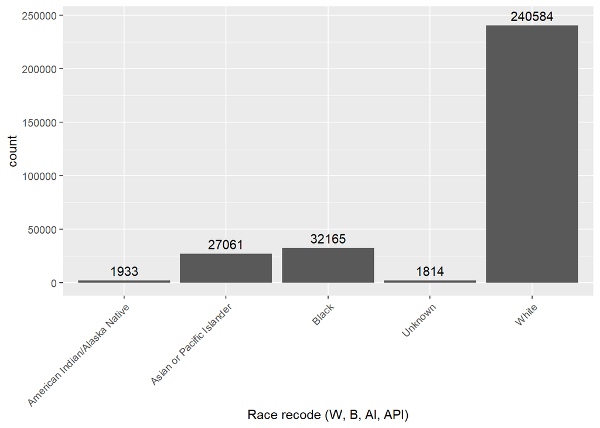

```r
#find column name to use later if needed
DF_col_names <- colnames(BREAST_DF_surv)

# use ggplot to plot the race information
BREAST_DF_surv |>
  ggplot(mapping = aes(x=`Race recode (W, B, AI, API)`)) +
  geom_bar(stat = "count") +
  theme(axis.text.x = element_text(angle = 45, hjust = 1)) +
  geom_text(aes(label = after_stat(count)), stat = "count", vjust = -0.5) +
  ylim(0, 246000)
```

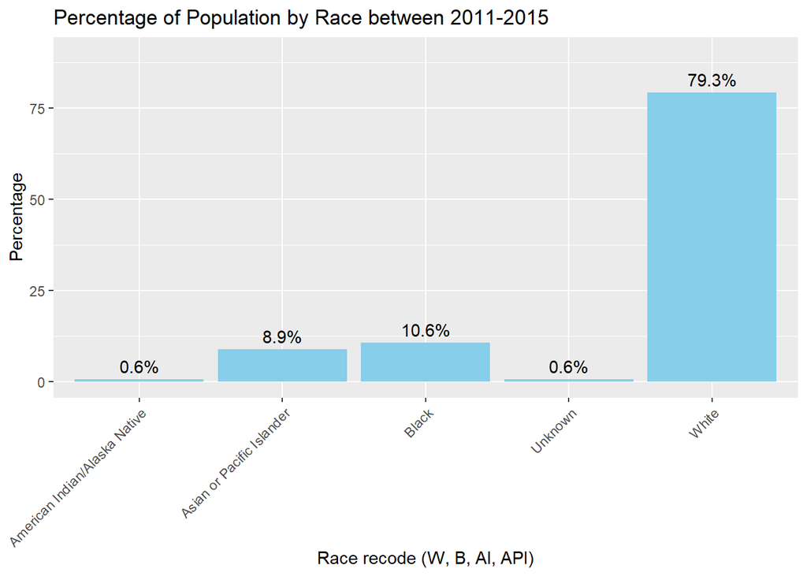

```r
#we want to compare the percentage of the different races in the eval and survival data, thus I use summarise to create two new DFs to only store the sumamry statistics specifically including the percentage of race based on the population
#find percentage of race for the survival
BREAST_DF_perc_surv <- BREAST_DF_surv %>%
  group_by(`Race recode (W, B, AI, API)`) %>%
  dplyr::summarise(count = dplyr::n()) %>%  # Calculate count per group
  ungroup() %>%  # Ungroup the data
  mutate(total_count = sum(count)) %>%  # Calculate total count
  mutate(percentage = count / total_count * 100)  # Calculate percentage using total count

# Plot the percentages
ggplot(BREAST_DF_perc_surv, aes(x = `Race recode (W, B, AI, API)`, y = percentage)) +
  geom_bar(stat = "identity", fill = "skyblue") +
  geom_text(aes(label = paste0(round(percentage, 1), "%")), vjust = -0.5, color = "black") +
  theme(axis.text.x = element_text(angle = 45, hjust = 1)) +
  labs(title = "Percentage of Population by Race between 2011-2015", x = "Race recode (W, B, AI, API)", y = "Percentage") + ylim (0,90)
```

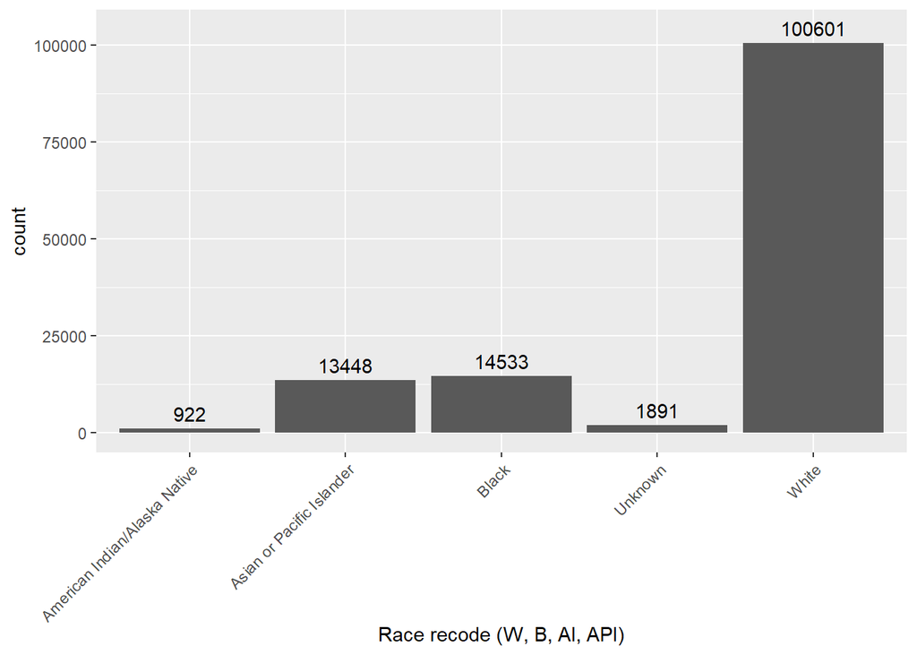

```r
BREAST_DF_eval |>
  ggplot(mapping = aes(x=`Race recode (W, B, AI, API)`)) +
  geom_bar(stat = "count") +
  theme(axis.text.x = element_text(angle = 45, hjust = 1)) +
  geom_text(aes(label = after_stat(count)), stat = "count", vjust = -0.5) +
  ylim(0, 104000)
```

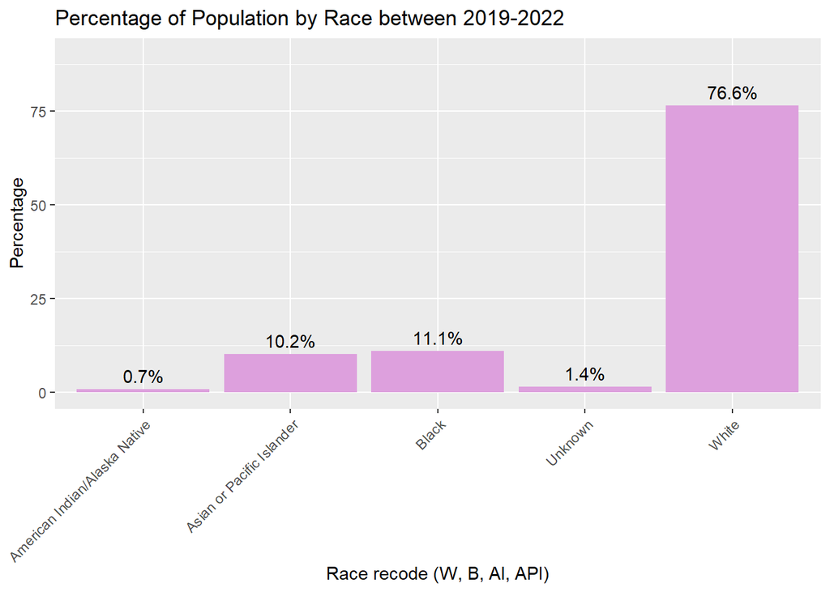

```r
BREAST_DF_perc_eval <- BREAST_DF_eval %>%
  group_by(`Race recode (W, B, AI, API)`) %>%
  dplyr::summarise(count = dplyr::n()) %>%  # Calculate count per group
  ungroup() %>%  # Ungroup the data
  mutate(total_count = sum(count)) %>%  # Calculate total count
  mutate(percentage = count / total_count * 100)  # Calculate percentage using total count

# Plot the percentages
ggplot(BREAST_DF_perc_eval, aes(x = `Race recode (W, B, AI, API)`, y = percentage)) +
  geom_bar(stat = "identity", fill = "plum") +
  geom_text(aes(label = paste0(round(percentage, 1), "%")), vjust = -0.5, color = "black") +
  theme(axis.text.x = element_text(angle = 45, hjust = 1)) +
  labs(title = "Percentage of Population by Race between 2019-2022", x = "Race recode (W, B, AI, API)", y = "Percentage") + ylim (0,90)
```

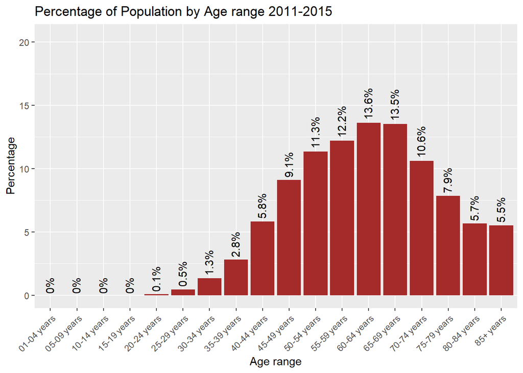

```r
# In this section I want to focus on the age and see if age matters, same sets of data is going to be plot for ages, starting with percentage for eval and surve
#find percentage of race for the survival
#find ubique values for column ratted to age
uniques_ages <- unique(BREAST_DF_surv[29])

BREAST_DF_age_perc_surv <- BREAST_DF_surv %>%
  dplyr::group_by(`Age recode (<60,60-69,70+)`) %>%
  dplyr::summarise(count = dplyr::n()) %>%  # Calculate count per group
  ungroup() %>%  # Ungroup the data
  mutate(total_count = sum(count)) %>%  # Calculate total count
  mutate(percentage = count / total_count * 100)  # Calculate percentage using total count

perc_max <- max(BREAST_DF_age_perc_surv$percentage)
# Plot the percentages
ggplot(BREAST_DF_age_perc_surv, aes(x = `Age recode (<60,60-69,70+)`, y = percentage)) +
  geom_bar(stat = "identity", fill = "brown") +
  geom_text(aes(label = paste0(round(percentage, 1), "%")), hjust = -0.1 , vjust = 0.4, color = "black", angle = 90) +  # Rotate the text vertically
  theme(axis.text.x = element_text(angle = 45, hjust = 1)) +labs(title = "Percentage of Population by Age range 2011-2015",
       x = "Age range",
       y = "Percentage") +
  ylim(0, round(1.5 * perc_max, 1))
```

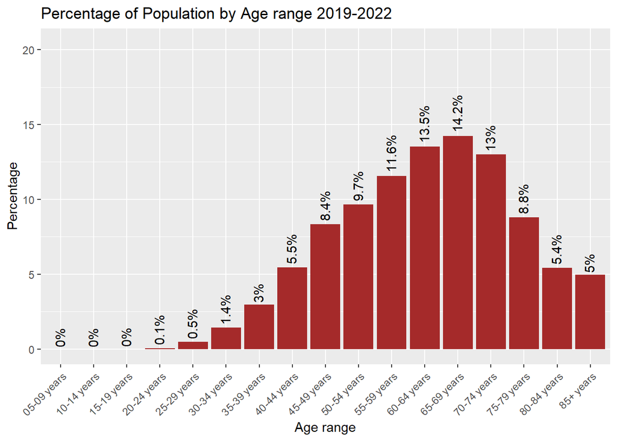

```r
# In this section we do the same analyses for Eval dta based on age
BREAST_DF_age_perc_eval <- BREAST_DF_eval %>%
  dplyr::group_by(`Age recode (<60,60-69,70+)`) %>%
  dplyr::summarise(count = dplyr::n()) %>%  # Calculate count per group
  ungroup() %>%  # Ungroup the data
  mutate(total_count = sum(count)) %>%  # Calculate total count
  mutate(percentage = count / total_count * 100)  # Calculate percentage using total count

# Plot the percentages
ggplot(BREAST_DF_age_perc_eval, aes(x = `Age recode (<60,60-69,70+)`, y = percentage)) +
  geom_bar(stat = "identity", fill = "brown") +
  geom_text(aes(label = paste0(round(percentage, 1), "%")), hjust = -0.1 , vjust = 0.4, color = "black", angle = 90) +  # Rotate the text vertically
  theme(axis.text.x = element_text(angle = 45, hjust = 1)) +labs(title = "Percentage of Population by Age range 2019-2022",
       x = "Age range",
       y = "Percentage") +
  ylim(0, round(1.5 * perc_max, 1))
```

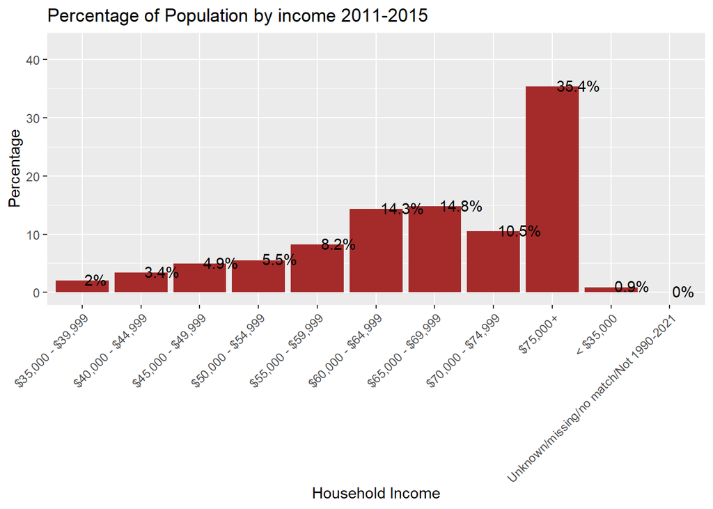

```r
# In this section, we do the analyses on household income
#find ubique values for column ratted to age
uniques_householdes <- unique(BREAST_DF_surv[27])

BREAST_DF_income_perc_surv <- BREAST_DF_surv %>% dplyr::group_by(`Median household income inflation adj to 2021`) %>%
  dplyr::summarise(count = dplyr::n()) %>% # Calculate count per group
  ungroup() %>% # Ungroup the data
  mutate(total_count = sum(count)) %>% # Calculate total count
  mutate(percentage = count / total_count * 100) # Calculate percentage using total count

perc_max <- max(BREAST_DF_income_perc_surv$percentage) # Plot the percentages
ggplot(BREAST_DF_income_perc_surv, aes(x = `Median household income inflation adj to 2021`, y = percentage)) +
  geom_bar(stat = "identity", fill = "brown") +
  geom_text(aes(label = paste0(round(percentage, 1), "%")), hjust = -0.1 , vjust = 0.4, color = "black", angle = 0) +
  theme(axis.text.x = element_text(angle = 45, hjust = 1)) +
  labs(title = "Percentage of Population by income 2011-2015", x = "Household Income", y = "Percentage") +
  ylim(0, 1.2*perc_max)
```

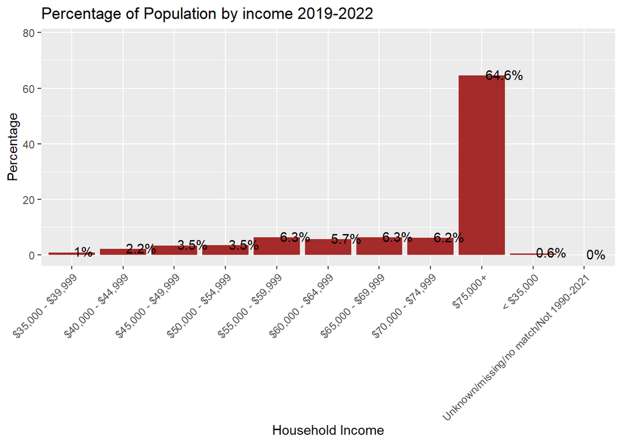

```r
#In this section we do the same analyses for Eval data based on age
BREAST_DF_income_perc_eval <- BREAST_DF_eval %>%
  dplyr::group_by(`Median household income inflation adj to 2021`) %>%
  dplyr::summarise(count = dplyr::n()) %>% # Calculate count per group
  ungroup() %>% # Ungroup the data
  mutate(total_count = sum(count)) %>% # Calculate total count
  mutate(percentage = count / total_count * 100) # Calculate percentage using total count


#Plot the percentages
perc_max <- max(BREAST_DF_income_perc_eval$percentage)
ggplot(BREAST_DF_income_perc_eval, aes(x = `Median household income inflation adj to 2021`, y = percentage)) +
  geom_bar(stat = "identity", fill = "brown") +
  geom_text(aes(label = paste0(round(percentage, 1), "%")), hjust = -0.1 , vjust = 0.4, color = "black", angle = 0) +
  theme(axis.text.x = element_text(angle = 45, hjust = 1)) +
  labs(title = "Percentage of Population by income 2019-2022", x = "Household Income", y = "Percentage") +
  ylim(0, 1.2*perc_max)
```

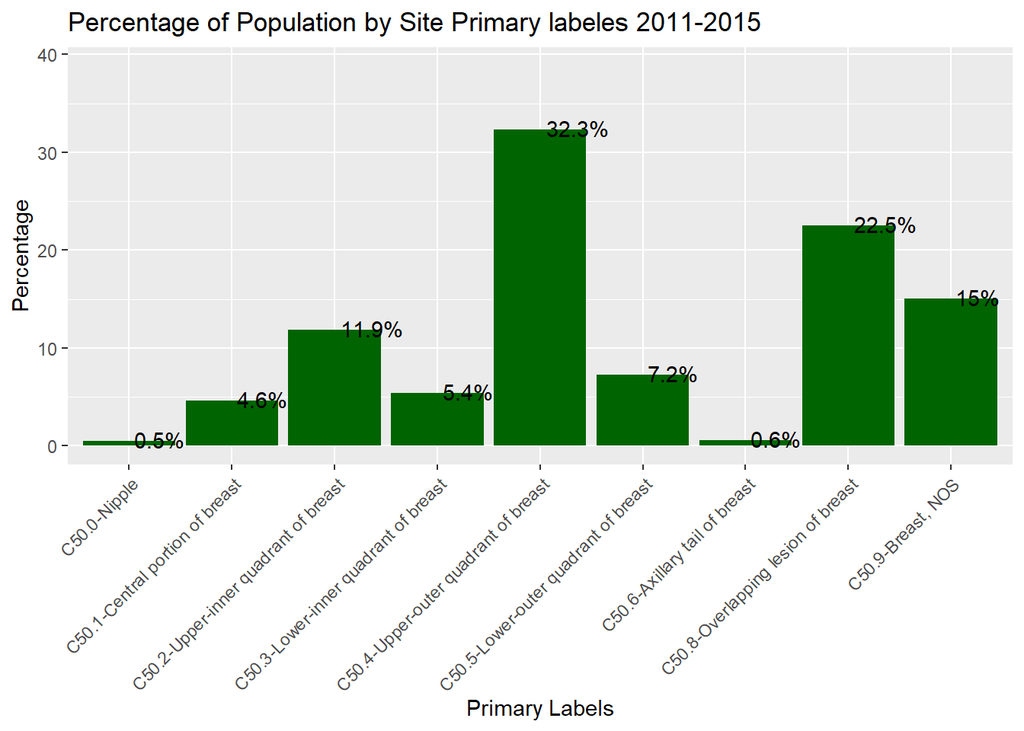

```r
# In this section, we do the analyses on Primary Site
#find ubique values for column ratted to age
uniques_canter_type <- unique(BREAST_DF_surv[27])

BREAST_DF_labeled_perc_surv <- BREAST_DF_surv %>% dplyr::group_by(`Primary Site - labeled`) %>%
  dplyr::summarise(count = dplyr::n()) %>% # Calculate count per group
  ungroup() %>% # Ungroup the data
  mutate(total_count = sum(count)) %>% # Calculate total count
  mutate(percentage = count / total_count * 100) # Calculate percentage using total count

perc_max <- max(BREAST_DF_labeled_perc_surv$percentage) # Plot the percentages
ggplot(BREAST_DF_labeled_perc_surv, aes(x = `Primary Site - labeled`, y = percentage)) +
  geom_bar(stat = "identity", fill = "darkgreen") +
  geom_text(aes(label = paste0(round(percentage, 1), "%")), hjust = -0.1 , vjust = 0.4, color = "black", angle = 0) +
  theme(axis.text.x = element_text(angle = 45, hjust = 1)) +
  labs(title = "Percentage of Population by Site Primary labeles 2011-2015", x = "Primary Labels", y = "Percentage") +
  ylim(0, 1.2*perc_max)
```

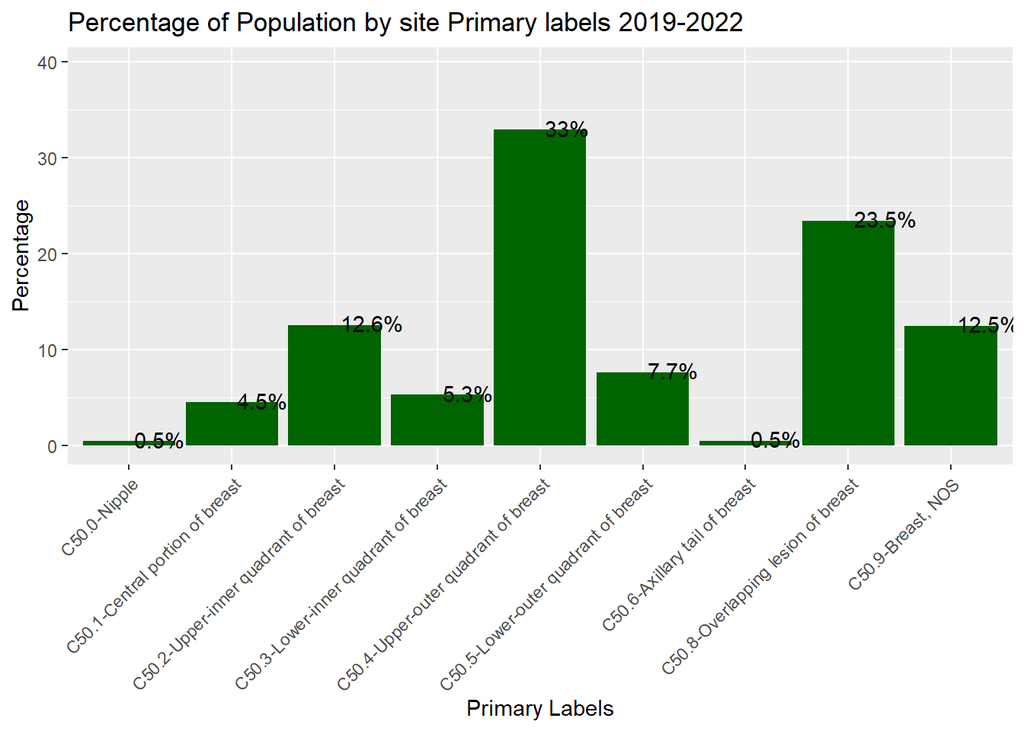

```r
#In this section we do the same analyses for Eval data based on age
BREAST_DF_labeled_perc_eval <- BREAST_DF_eval %>%
  dplyr::group_by(`Primary Site - labeled`) %>%
  dplyr::summarise(count = dplyr::n()) %>% # Calculate count per group
  ungroup() %>% # Ungroup the data
  mutate(total_count = sum(count)) %>% # Calculate total count
  mutate(percentage = count / total_count * 100) # Calculate percentage using total count


#Plot the percentages
perc_max <- max(BREAST_DF_labeled_perc_eval$percentage)
ggplot(BREAST_DF_labeled_perc_eval, aes(x = `Primary Site - labeled`, y = percentage)) +
  geom_bar(stat = "identity", fill = "darkgreen") +
  geom_text(aes(label = paste0(round(percentage, 1), "%")), hjust = -0.1 , vjust = 0.4, color = "black", angle = 0) +
  theme(axis.text.x = element_text(angle = 45, hjust = 1)) +
  labs(title = "Percentage of Population by site Primary labels 2019-2022", x = "Primary Labels", y = "Percentage") +
  ylim(0, 1.2*perc_max)
```

```r
# check if the column `COD to site recode` has value of Alive or Breast meaning they are still alive or have died because of breast cancer, and other passed a way but not because of Breast cancer.

BREAST_DF_surv <- BREAST_DF_surv %>%
  mutate(COD = ifelse(`COD to site recode` %in% c("Alive","Breast"), `COD to site recode`, "Other"))
```

## Results of the exploratory data analysis

In this section, we look into some exploratory data analysis such as

- Cause of death of those who have had cancer
- Total number of tumors (Malignant or Benign)
- Radiation and chemotherapy
- Surgery Performed
- Marital Status
- Household income

We looked into the population and then among the population how many survived the cancer. Later we will run some analyses to see whether those were important or deciding factors or not.

```r
BREAST_DF_COD_perc_surv <- BREAST_DF_surv %>%
  dplyr::group_by(COD) %>%
  dplyr::summarise(count = dplyr::n()) %>%  # Calculate count per group
  ungroup() %>%  # Ungroup the data
  mutate(`Total Count` = sum(count)) %>%  # Calculate total count
  mutate(Population = round(count / `Total Count` * 100),2)  # Calculate percentage using total count

kable(BREAST_DF_COD_perc_surv)
```

| COD | count | Total Count | Population | 2 |
| --- | --- | --- | --- | --- |
| Alive | 228221 | 303557 | 75 | 2 |
| Breast | 38472 | 303557 | 13 | 2 |
| Other | 36864 | 303557 | 12 | 2 |

```r
# Let’s first group by the number of tumors and find out how many people in the population have them. Then, among those individuals, let’s determine how many passed away solely due to breast cancer. However, it’s important to note that this approach may not be completely accurate, as there could be cases where individuals passed away due to breast cancer complications that are not accounted for in these counts.”

BREAST_DF_TNoT_perc_surv <- BREAST_DF_surv %>%
  dplyr::group_by(`Total number of in situ/malignant tumors for patient`) %>%
  dplyr::add_count() %>%
  filter(COD == "Breast") %>%
  dplyr::summarise(`Event Population` = n(),
            Population = dplyr::first(n))  # Use `first()` to extract the total count in each

# Do simple math to fidn the percentage of the group in the population and then the percentage of the deceased within the group.

BREAST_DF_TNoT_perc_surv$`Group % in total` <- round(BREAST_DF_TNoT_perc_surv$Population/sum(BREAST_DF_TNoT_perc_surv$Population)*100,2)

BREAST_DF_TNoT_perc_surv$`Death %` <- round(BREAST_DF_TNoT_perc_surv$`Event Population`/BREAST_DF_TNoT_perc_surv$Population*100,2)


kable(BREAST_DF_TNoT_perc_surv)
```

| Total number of in situ/malignant tumors for patient | Event Population | Population | Group % in total | Death % |
| --- | --- | --- | --- | --- |
| 1 | 27314 | 217122 | 71.53 | 12.58 |
| 2 | 8945 | 68082 | 22.43 | 13.14 |
| 3 | 1808 | 14579 | 4.80 | 12.40 |
| 4 | 322 | 2996 | 0.99 | 10.75 |
| 5 | 68 | 595 | 0.20 | 11.43 |
| 6 | 9 | 126 | 0.04 | 7.14 |
| 7 | 3 | 29 | 0.01 | 10.34 |
| 8 | 2 | 18 | 0.01 | 11.11 |
| 18 | 1 | 1 | 0.00 | 100.00 |

```r
# Let' focus on the treatemnt, There are two type of treatment and can be a 4 combination, as follows: Radiation: R, Chemoteraphy: C,  R:N-C:N,  R:Y-C:N, R:N-C:Y, R:Y-C:Y. We must look into these 4 group and find the total number and then in each find the number of death. Finally report them imialrly that we have done above.

BREAST_DF_surv <- BREAST_DF_surv %>%
  mutate(Radiation = ifelse(`Radiation recode` %in% c("None/Unknown","Refused (1988+)","Recommended, unknown if administered"),"No/Unknown","Yes"))
BREAST_DF_eval <- BREAST_DF_eval %>%
  mutate(Radiation = ifelse(`Radiation recode` %in% c("None/Unknown","Refused (1988+)","Recommended, unknown if administered"),"No/Unknown","Yes"))

#use DPLYR to filter based on two parameters chemotheraphy and radiation therapy and evalaute the death rate accordingly
BREAST_DF_RNC_perc_surv <- BREAST_DF_surv %>%
  dplyr::group_by(Radiation,`Chemotherapy recode (yes, no/unk)`) %>%
  dplyr::add_count() %>%
  filter(COD == "Breast") %>%
  dplyr::summarise(`Event Population` = n(),
            Population = dplyr::first(n))  # Use `first()` to extract the total count in each
# Replace "No/Unknown" with "No" in the original columns
BREAST_DF_RNC_perc_surv$Radiation <- ifelse(BREAST_DF_RNC_perc_surv$Radiation == "No/Unknown", "No", BREAST_DF_RNC_perc_surv$Radiation)

BREAST_DF_RNC_perc_surv$"Chemotherapy recode (yes, no/unk)" <- ifelse(BREAST_DF_RNC_perc_surv$"Chemotherapy recode (yes, no/unk)" == "No/Unknown", "No", BREAST_DF_RNC_perc_surv$"Chemotherapy recode (yes, no/unk)")

# Create a new column "Radiation_Chemo" with values separated by "/"
BREAST_DF_RNC_perc_surv$Radiation_Chemo <- paste(BREAST_DF_RNC_perc_surv$Radiation, BREAST_DF_RNC_perc_surv$"Chemotherapy recode (yes, no/unk)", sep = "/")


# Optionally, remove the original "Radiation" and "Chemotherapy recode (yes, no/unk)" columns
BREAST_DF_RNC_perc_surv <- subset(BREAST_DF_RNC_perc_surv, select = -c(Radiation, `Chemotherapy recode (yes, no/unk)`))

BREAST_DF_RNC_perc_surv <- BREAST_DF_RNC_perc_surv[, c("Radiation_Chemo", setdiff(names(BREAST_DF_RNC_perc_surv), "Radiation_Chemo"))]


# Reshape the dataframe from wide to long format

#knowing the population calcualte the gorup rate and death rate in each group
BREAST_DF_RNC_perc_surv$`Group % in total` <- round(BREAST_DF_RNC_perc_surv$Population/sum(BREAST_DF_RNC_perc_surv$Population)*100,2)

BREAST_DF_RNC_perc_surv$`Death %` <- round(BREAST_DF_RNC_perc_surv$`Event Population`/BREAST_DF_RNC_perc_surv$Population*100,2)



kable(BREAST_DF_RNC_perc_surv)
```

| Radiation_Chemo | Event Population | Population | Group % in total | Death % |
| --- | --- | --- | --- | --- |
| No/No | 15684 | 107012 | 35.25 | 14.66 |
| No/Yes | 9929 | 54966 | 18.11 | 18.06 |
| Yes/No | 3731 | 79926 | 26.33 | 4.67 |
| Yes/Yes | 9128 | 61653 | 20.31 | 14.81 |

```r
#next let's look into the surgery and the survival rate and whether it migth have been critical or not.
BREAST_DF_SUR_perc_surv <- BREAST_DF_surv %>%
  dplyr::group_by(`Reason no cancer-directed surgery`) %>%
  dplyr::add_count() %>%
  filter(COD == "Breast") %>%
  dplyr::summarise(`Event Population` = n(),
            Population = dplyr::first(n))  # Use `first()` to extract the total

#knowing the population calcualte the gorup rate and death rate in each group
BREAST_DF_SUR_perc_surv$`Group % in total` <- round(BREAST_DF_SUR_perc_surv$Population/sum(BREAST_DF_SUR_perc_surv$Population)*100,2)

BREAST_DF_SUR_perc_surv$`Death %` <- round(BREAST_DF_SUR_perc_surv$`Event Population`/BREAST_DF_SUR_perc_surv$Population*100,2)

kable(BREAST_DF_SUR_perc_surv)
```

| Reason no cancer-directed surgery | Event Population | Population | Group % in total | Death % |
| --- | --- | --- | --- | --- |
| Not performed, patient died prior to recommended surgery | 139 | 278 | 0.09 | 50.00 |
| Not recommended | 11636 | 23199 | 7.64 | 50.16 |
| Not recommended, contraindicated due to other cond; autopsy only (1973-2002) | 593 | 1356 | 0.45 | 43.73 |
| Recommended but not performed, patient refused | 1171 | 2608 | 0.86 | 44.90 |
| Recommended but not performed, unknown reason | 545 | 1604 | 0.53 | 33.98 |
| Recommended, unknown if performed | 613 | 2649 | 0.87 | 23.14 |
| Surgery performed | 22376 | 269730 | 88.86 | 8.30 |
| Unknown; death certificate; or autopsy only (2003+) | 1399 | 2133 | 0.70 | 65.59 |

```r
#next let's look into the marital status and the survival rate and whether it migth have been critical or not.
BREAST_DF_MARI_perc_surv <- BREAST_DF_surv %>%
  dplyr::group_by(`Marital status at diagnosis`) %>%
  dplyr::add_count() %>%
  filter(COD == "Breast") %>%
  dplyr::summarise(`Event Population` = n(),
            Population = dplyr::first(n))  # Use `first()` to extract the total

#knowing the population calcualte the gorup rate and death rate in each group
BREAST_DF_MARI_perc_surv$`Group % in total` <- round(BREAST_DF_MARI_perc_surv$Population/sum(BREAST_DF_MARI_perc_surv$Population)*100,2)

BREAST_DF_MARI_perc_surv$`Death %` <- round(BREAST_DF_MARI_perc_surv$`Event Population`/BREAST_DF_MARI_perc_surv$Population*100,2)

kable(BREAST_DF_MARI_perc_surv)
```

| Marital status at diagnosis | Event Population | Population | Group % in total | Death % |
| --- | --- | --- | --- | --- |
| Divorced | 4399 | 32214 | 10.61 | 13.66 |
| Married (including common law) | 15694 | 160551 | 52.89 | 9.78 |
| Separated | 544 | 3225 | 1.06 | 16.87 |
| Single (never married) | 7161 | 44678 | 14.72 | 16.03 |
| Unknown | 2774 | 18481 | 6.09 | 15.01 |
| Unmarried or Domestic Partner | 110 | 1014 | 0.33 | 10.85 |
| Widowed | 7790 | 43394 | 14.30 | 17.95 |

```r
#next let's look into the Median household income and the survival rate and whether it migth have been critical or not.
BREAST_DF_HHI_perc_surv <- BREAST_DF_surv %>%
  dplyr::group_by(`Median household income inflation adj to 2021`) %>%
  dplyr::add_count() %>%
  filter(COD == "Breast") %>%
  dplyr::summarise(`Event Population` = n(),
            Population = dplyr::first(n))  # Use `first()` to extract the total

#knwoign the population calcualte the gorup rate and death rate in each group
BREAST_DF_HHI_perc_surv$`Group % in total` <- round(BREAST_DF_HHI_perc_surv$Population/sum(BREAST_DF_HHI_perc_surv$Population)*100,2)

BREAST_DF_HHI_perc_surv$`Death %` <- round(BREAST_DF_HHI_perc_surv$`Event Population`/BREAST_DF_HHI_perc_surv$Population*100,2)

kable(BREAST_DF_HHI_perc_surv)
```

| Median household income inflation adj to 2021 | Event Population | Population | Group % in total | Death % |
| --- | --- | --- | --- | --- |
| $35,000 - $39,999 | 1000 | 6077 | 2.00 | 16.46 |
| $40,000 - $44,999 | 1630 | 10225 | 3.37 | 15.94 |
| $45,000 - $49,999 | 2289 | 14917 | 4.91 | 15.34 |
| $50,000 - $54,999 | 2310 | 16794 | 5.53 | 13.75 |
| $55,000 - $59,999 | 3371 | 24860 | 8.19 | 13.56 |
| $60,000 - $64,999 | 6010 | 43537 | 14.34 | 13.80 |
| $65,000 - $69,999 | 5848 | 44978 | 14.82 | 13.00 |
| $70,000 - $74,999 | 3927 | 31930 | 10.52 | 12.30 |
| $75,000+ | 11608 | 107459 | 35.40 | 10.80 |
| < $35,000 | 469 | 2716 | 0.89 | 17.27 |
| Unknown/missing/no match/Not 1990-2021 | 10 | 64 | 0.02 | 15.62 |

```r
#next let's look into the Type of Cancer and the survival rate and whether it migth have been critical or not.
BREAST_DF_PSL_perc_surv <- BREAST_DF_surv %>%
  dplyr::group_by(`Primary Site - labeled`) %>%
  dplyr::add_count() %>%
  filter(COD == "Breast") %>%
  dplyr::summarise(`Event Population` = n(),
            Population = dplyr::first(n))  # Use `first()` to extract the total

#knwoign the population calcualte the gorup rate and death rate in each group
BREAST_DF_PSL_perc_surv$`Group % in total` <- round(BREAST_DF_PSL_perc_surv$Population/sum(BREAST_DF_PSL_perc_surv$Population)*100,2)

BREAST_DF_PSL_perc_surv$`Death %` <- round(BREAST_DF_PSL_perc_surv$`Event Population`/BREAST_DF_PSL_perc_surv$Population*100,2)

kable(BREAST_DF_PSL_perc_surv)
```

| Primary Site - labeled | Event Population | Population | Group % in total | Death % |
| --- | --- | --- | --- | --- |
| C50.0-Nipple | 173 | 1477 | 0.49 | 11.71 |
| C50.1-Central portion of breast | 2043 | 14012 | 4.62 | 14.58 |
| C50.2-Upper-inner quadrant of breast | 3058 | 36006 | 11.86 | 8.49 |
| C50.3-Lower-inner quadrant of breast | 1572 | 16365 | 5.39 | 9.61 |
| C50.4-Upper-outer quadrant of breast | 9710 | 98199 | 32.35 | 9.89 |
| C50.5-Lower-outer quadrant of breast | 2287 | 21939 | 7.23 | 10.42 |
| C50.6-Axillary tail of breast | 270 | 1685 | 0.56 | 16.02 |
| C50.8-Overlapping lesion of breast | 7514 | 68285 | 22.49 | 11.00 |
| C50.9-Breast, NOS | 11845 | 45589 | 15.02 | 25.98 |

[figure not shown]

```r
# Create a list to store all your dataframes
DF_names <- c (
  "BREAST_DF_TNoT_perc_surv",
  "BREAST_DF_RNC_perc_surv",
  "BREAST_DF_SUR_perc_surv",
  "BREAST_DF_MARI_perc_surv",
  "BREAST_DF_HHI_perc_surv",
  "BREAST_DF_PSL_perc_surv")

# Create an empty list to store plots
plot_list <- list()
chart_color <- c("plum", "darkgreen", "darkred", "darkblue", "darkorange", "darkmagenta",
                 "darkcyan", "purple", "lightblue", "darkgray", "lightpink", "blue",
                 "brown", "red")
chart_title <- c("# of Malignant Tumors",
                 "Radiation/Chemo Status",
                 "Cancer Surgery",
                 "Marital Status",
                 "Household Income",
                 "Primary Site Labeled")
set.seed(2014)
# Loop through each dataframe
for (i in 1:length(DF_names)) {
  # Access the dataframe
  df <- get(DF_names[i])

  # Generate a random color
  random_color <- sample(chart_color, 1)

  # Get the name of the first column and wrap the text
  column_name <- str_wrap(names(df)[1], width = 10)  # Adjust width as needed

  # Create the plot and store it in the plot list
  plot <- ggplot(df, aes(x = !!rlang::sym(names(df)[1]), y = !!rlang::sym("Death %"))) +
    geom_bar(stat = "identity", fill = random_color) +
    labs(title = chart_title[i],
         x = NULL, y = "Death %") +  # Remove x-axis label
    theme(axis.text.x = element_text(angle = 45, hjust = 1, vjust = 1))  # Rotate x-axis labels

  plot_list[[i]] <- plot
}

# Arrange the plots in a 2 by 3 matrix
grid.arrange(grobs = plot_list, ncol = 3)
```

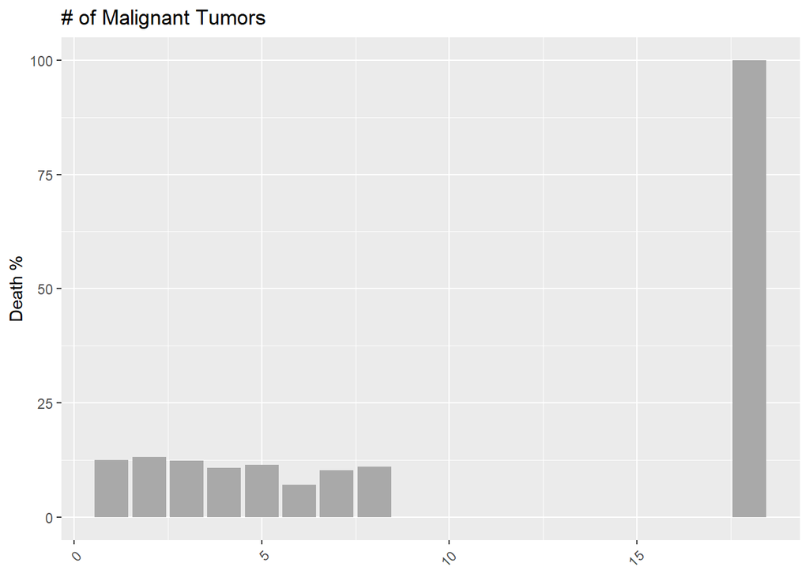

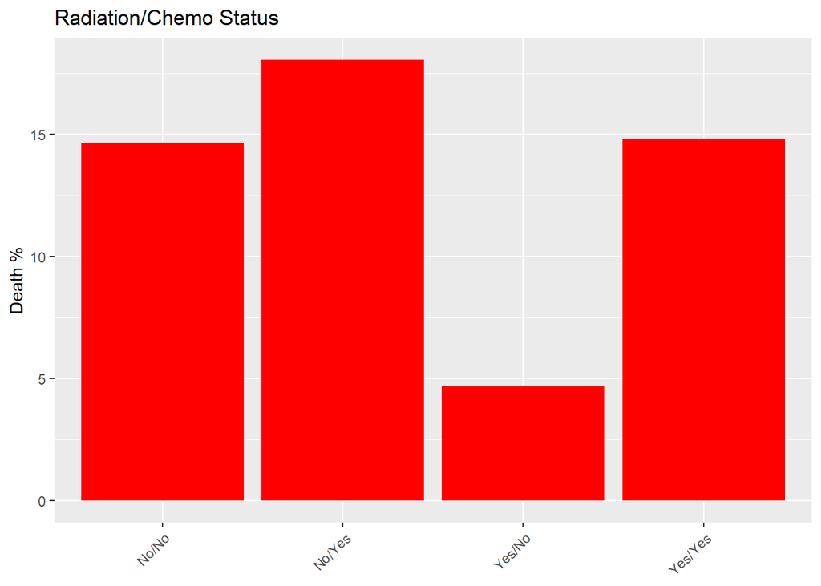

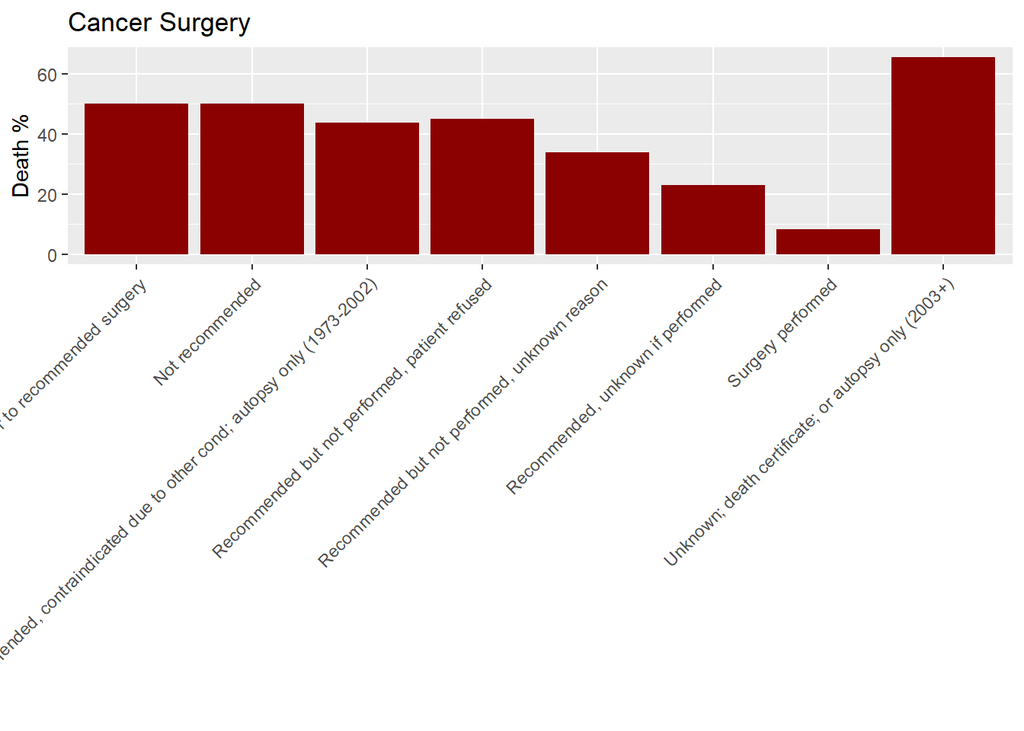

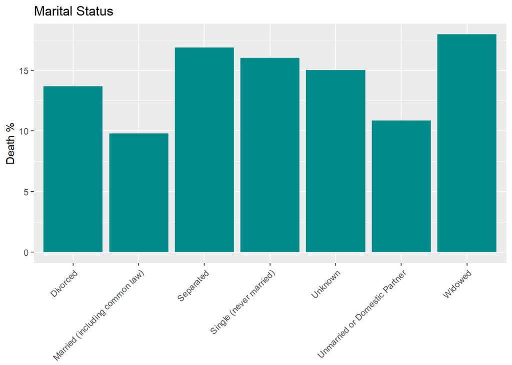

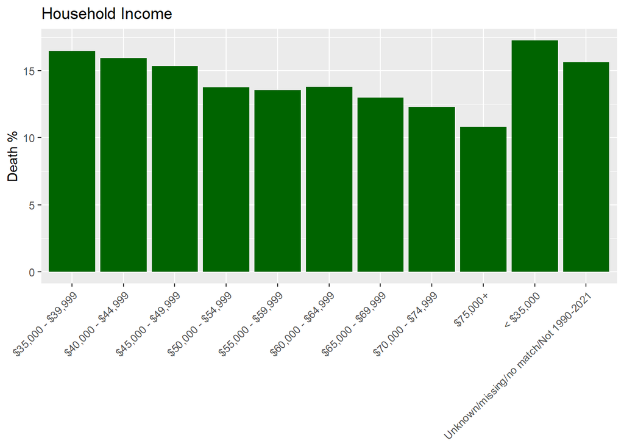

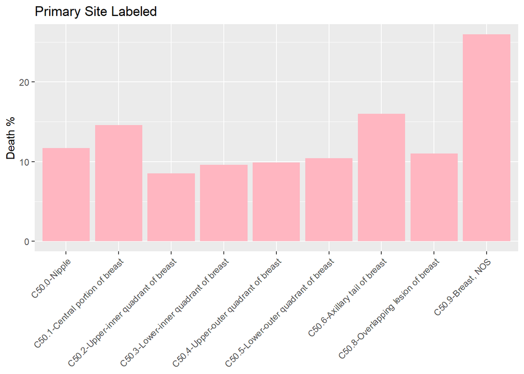

```r
# Plot individually
# Plot individually

# Loop through each dataframe
for (i in 1:length(DF_names)) {
  # Access the dataframe
  df <- get(DF_names[i])

  # Generate a random color
  random_color <- sample(chart_color, 1)

  # Get the name of the first column and wrap the text
  column_name <- str_wrap(names(df)[1], width = 10)  # Adjust width as needed

  # Create the plot and store it in the plot list
  plot <- ggplot(df, aes(x = !!rlang::sym(names(df)[1]), y = !!rlang::sym("Death %"))) +
    geom_bar(stat = "identity", fill = random_color) +
    labs(title = chart_title[i],
         x = NULL, y = "Death %") +  # Remove x-axis label
    theme(axis.text.x = element_text(angle = 45, hjust = 1, vjust = 1))  # Rotate x-axis labels

  # Print the plot
  print(plot)
}
```

## Correlation investigation

In this section we will be using different R packages to perform correlation and other analyses on the data, to do so, we first need to slightly change our data to make them suitable for packages like `survival`, `purrr`, `caret`, `GGally,` and so forth.

The first step is to change the categorical data to factor in columns that they exist. Then we use the `purrr` to calculate chi-square and Fisher exact test for different variables. Since the size of the population is large, we will do bootstrap and p-simulation to calculate the p_value to find the importance of different variables.

The strategy is to find the one with the highest effect in theory, the code will calculate the p-values from chi-squared/Fisher’s exact test for independence between each categorical variable and the `COD` (Cause of death) column. The lower the p-value, the stronger the evidence against the null hypothesis of independence, suggesting a significant association between the variable and `COD`. Then we simplify the model by keeping the most relevant, we also need to look into **homoscedasticity** and remove those that may contribute to.

### Fisher_test and chi-Square

```r
# List of columns to remove
uncritical_column <- c("Sex", "Year of diagnosis",
                       "Race and origin recode (NHW, NHB, NHAIAN, NHAPI, Hispanic)",
                       "Site recode ICD-O-3/WHO 2008", "Site recode ICD-O-3 2023 Revision",
                       "Diagnostic Confirmation, Survival months flag", "COD to site recode",
                       "Patient ID", "Year of follow-up recode", "Year of death recode",
                       "SEER other cause of death classification",
                       "RX Summ--Systemic/Sur Seq (2007+)",
                       "Origin recode NHIA (Hispanic, Non-Hisp)",
                       "Race and origin (recommended by SEER)",
                       "Diagnostic Confirmation",
                       "Sequence number", "Radiation recode")

# Create BREAST_DF_surv_clean by removing uncritical columns
BREAST_DF_surv_clean <- BREAST_DF_surv[, !names(BREAST_DF_surv) %in% uncritical_column]
BREAST_DF_eval_clean <- BREAST_DF_eval[, !names(BREAST_DF_eval) %in% uncritical_column]


# Identify character and numeric columns
char_cols <- sapply(BREAST_DF_surv_clean, is.character)
num_cols <- sapply(BREAST_DF_surv_clean, is.numeric)
char_cols_e <- sapply(BREAST_DF_eval_clean, is.character)

# Convert character columns to factors
BREAST_DF_surv_clean[char_cols] <- lapply(BREAST_DF_surv_clean[char_cols], as.factor)
BREAST_DF_eval_clean[char_cols_e] <- lapply(BREAST_DF_eval_clean[char_cols_e], as.factor)
#BREAST_DF_surv[num_cols] <- lapply(BREAST_DF_surv[num_cols], as.factor)

# Check the class of each column to ensure they are factors now
#sapply(BREAST_DF_surv, class)


#check to esure all variable have more than two levels
one_level_vars <- sapply(BREAST_DF_surv_clean, function(x) length(unique(x)) == 1)
# Print variables with only one level
one_level_vars_names <- names(one_level_vars)[one_level_vars]
#print(names(one_level_vars)[one_level_vars])

# Remove variables with only one level from the data frame
BREAST_DF_surv_clean <- BREAST_DF_surv_clean[, !names(BREAST_DF_surv_clean) %in% one_level_vars_names]
BREAST_DF_eval_clean <- BREAST_DF_eval_clean[, !names(BREAST_DF_eval_clean) %in% one_level_vars_names]


skimr::skim(BREAST_DF_surv_clean)
```

Data summary

| Name | BREAST_DF_surv_clean |
| --- | --- |
| Number of rows | 303557 |
| Number of columns | 18 |
| _______________________ |  |
| Column type frequency: |  |
| factor | 14 |
| numeric | 4 |
| ________________________ |  |
| Group variables | None |

**Variable type: factor**

| skim_variable | n_missing | complete_rate | ordered | n_unique | top_counts |
| --- | --- | --- | --- | --- | --- |
| Race recode (W, B, AI, API) | 0 | 1 | FALSE | 5 | Whi: 240584, Bla: 32165, Asi: 27061, Ame: 1933 |
| Primary Site - labeled | 0 | 1 | FALSE | 9 | C50: 98199, C50: 68285, C50: 45589, C50: 36006 |
| Grade Recode (thru 2017) | 0 | 1 | FALSE | 5 | Mod: 119566, Poo: 84251, Wel: 64536, Unk: 34855 |
| Laterality | 0 | 1 | FALSE | 5 | Lef: 152350, Rig: 147730, Pai: 3152, Onl: 190 |
| Chemotherapy recode (yes, no/unk) | 0 | 1 | FALSE | 2 | No/: 186938, Yes: 116619 |
| Reason no cancer-directed surgery | 0 | 1 | FALSE | 8 | Sur: 269730, Not: 23199, Rec: 2649, Rec: 2608 |
| Survival months flag | 0 | 1 | FALSE | 5 | Com: 295136, Inc: 6620, Not: 1290, Com: 376 |
| First malignant primary indicator | 0 | 1 | FALSE | 2 | Yes: 252683, No: 50874 |
| Marital status at diagnosis | 0 | 1 | FALSE | 7 | Mar: 160551, Sin: 44678, Wid: 43394, Div: 32214 |
| Median household income inflation adj to 2021 | 0 | 1 | FALSE | 11 | $75: 107459, $65: 44978, $60: 43537, $70: 31930 |
| Rural-Urban Continuum Code | 0 | 1 | FALSE | 7 | Cou: 185374, Cou: 65041, Cou: 21239, Non: 18125 |
| Age recode (<60,60-69,70+) | 0 | 1 | FALSE | 18 | 60-: 41318, 65-: 41060, 55-: 37068, 50-: 34424 |
| COD | 0 | 1 | FALSE | 3 | Ali: 228221, Bre: 38472, Oth: 36864 |
| Radiation | 0 | 1 | FALSE | 2 | No/: 161978, Yes: 141579 |

**Variable type: numeric**

| skim_variable | n_missing | complete_rate | mean | sd | p0 | p25 | p50 | p75 | p100 | hist |
| --- | --- | --- | --- | --- | --- | --- | --- | --- | --- | --- |
| Months from diagnosis to treatment | 15843 | 0.95 | 1.13 | 1.14 | 0 | 0 | 1 | 2 | 24 | ▇▁▁▁▁ |
| Survival months | 1290 | 1.00 | 74.22 | 29.88 | 0 | 62 | 78 | 97 | 119 | ▂▂▆▇▆ |
| Total number of in situ/malignant tumors for patient | 3 | 1.00 | 1.36 | 0.65 | 1 | 1 | 1 | 2 | 20 | ▇▁▁▁▁ |
| Total number of benign/borderline tumors for patient | 0 | 1.00 | 0.01 | 0.09 | 0 | 0 | 0 | 0 | 5 | ▇▁▁▁▁ |

```r
skimr::skim(BREAST_DF_eval_clean)
```

Data summary

| Name | BREAST_DF_eval_clean |
| --- | --- |
| Number of rows | 131395 |
| Number of columns | 17 |
| _______________________ |  |
| Column type frequency: |  |
| factor | 13 |
| numeric | 4 |
| ________________________ |  |
| Group variables | None |

**Variable type: factor**

| skim_variable | n_missing | complete_rate | ordered | n_unique | top_counts |
| --- | --- | --- | --- | --- | --- |
| Race recode (W, B, AI, API) | 0 | 1 | FALSE | 5 | Whi: 100601, Bla: 14533, Asi: 13448, Unk: 1891 |
| Primary Site - labeled | 0 | 1 | FALSE | 9 | C50: 43321, C50: 30822, C50: 16539, C50: 16423 |
| Grade Recode (thru 2017) | 0 | 1 | FALSE | 1 | Unk: 131395 |
| Laterality | 0 | 1 | FALSE | 5 | Lef: 66096, Rig: 63885, Pai: 1317, Bil: 52 |
| Chemotherapy recode (yes, no/unk) | 0 | 1 | FALSE | 2 | No/: 83776, Yes: 47619 |
| Reason no cancer-directed surgery | 0 | 1 | FALSE | 8 | Sur: 114210, Not: 12567, Rec: 1144, Rec: 1111 |
| Survival months flag | 0 | 1 | FALSE | 5 | Com: 128932, Inc: 1037, Com: 633, Not: 537 |
| First malignant primary indicator | 0 | 1 | FALSE | 2 | Yes: 107910, No: 23485 |
| Marital status at diagnosis | 0 | 1 | FALSE | 7 | Mar: 70613, Sin: 20883, Wid: 16724, Div: 13667 |
| Median household income inflation adj to 2021 | 0 | 1 | FALSE | 11 | $75: 84913, $55: 8336, $65: 8298, $70: 8158 |
| Rural-Urban Continuum Code | 0 | 1 | FALSE | 7 | Cou: 80172, Cou: 28055, Cou: 9574, Non: 7900 |
| Age recode (<60,60-69,70+) | 0 | 1 | FALSE | 17 | 65-: 18702, 60-: 17760, 70-: 17096, 55-: 15189 |
| Radiation | 0 | 1 | FALSE | 2 | Yes: 65993, No/: 65402 |

**Variable type: numeric**

| skim_variable | n_missing | complete_rate | mean | sd | p0 | p25 | p50 | p75 | p100 | hist |
| --- | --- | --- | --- | --- | --- | --- | --- | --- | --- | --- |
| Months from diagnosis to treatment | 6807 | 0.95 | 1.26 | 1.18 | 0 | 1 | 1 | 2 | 24 | ▇▁▁▁▁ |
| Survival months | 537 | 1.00 | 11.07 | 7.05 | 0 | 5 | 11 | 17 | 23 | ▇▆▆▇▆ |
| Total number of in situ/malignant tumors for patient | 11 | 1.00 | 1.31 | 0.62 | 1 | 1 | 1 | 1 | 50 | ▇▁▁▁▁ |
| Total number of benign/borderline tumors for patient | 0 | 1.00 | 0.01 | 0.09 | 0 | 0 | 0 | 0 | 2 | ▇▁▁▁▁ |

```r
# Function to calculate chi-squared test for independence
chi_squared_cal <- function(var, data) {
  tab <- table(data$COD, var)
  chisq_result <- chisq.test(tab)
  p_value <- chisq_result$p.value
  return(p_value)
}

# Function to calculate Sisher-Exact test for independence
fisher_exact_cal <- function(var, data) {
  tab <- table(data$COD, var)
  # Perform Fisher's exact test
  fisher_result <- fisher.test(tab, simulate.p.value = TRUE)
  # Extract the p-value
  p_value <- fisher_result$p.value
  return(p_value)
}


# Initialize an empty list to store p-values
p_values <- list()

# Number of bootstrap samples
n_bootstrap <- 50

#I perform bootsrap and downasampling to eliminate the population effect on chi-square, still the correlation seems high with all be so close to 0
# Loop over each column in the dataframe
for (col in names(BREAST_DF_surv_clean)) {
  # Check if the column is a factor
  if (is.factor(BREAST_DF_surv_clean[[col]])) {
    # Initialize an empty vector to store p-values from bootstrap samples
    bootstrap_p_values <- numeric(n_bootstrap)

    # Perform bootstrap sampling and calculate chi-squared p-value for each sample
    for (i in 1:n_bootstrap) {
      # Generate a bootstrap sample with replacement
      bootstrap_data <-
        BREAST_DF_surv_clean[sample(nrow(BREAST_DF_surv_clean),
                                    size = 0.05 * nrow(BREAST_DF_surv_clean),
                                    replace = TRUE), ]

      # Calculate chi-squared p-value for the bootstrap sample
      #bootstrap_p_values[i] <- chi_squared_cal(bootstrap_data[[col]], bootstrap_data)
      bootstrap_p_values[i] <- fisher_exact_cal(bootstrap_data[[col]], bootstrap_data)
    }

    # Calculate the mean p-value from bootstrap samples
    mean_p_value <- mean(bootstrap_p_values)

    # Store the mean p-value for the column
    p_values[[col]] <- mean_p_value
  }
}

# Convert the list of p-values to a data frame
p_values_df <- data.frame(variable = names(p_values), p_value = unlist(p_values))

# Sort the results by p-values
sorted_results <- p_values_df[order(p_values_df$p_value, na.last = TRUE), ]

# Print the sorted p-values
kable(sorted_results)
```

|  | variable | p_value |
| --- | --- | --- |
| Race recode (W, B, AI, API) | Race recode (W, B, AI, API) | 0.0004998 |
| Primary Site - labeled | Primary Site - labeled | 0.0004998 |
| Grade Recode (thru 2017) | Grade Recode (thru 2017) | 0.0004998 |
| Laterality | Laterality | 0.0004998 |
| Chemotherapy recode (yes, no/unk) | Chemotherapy recode (yes, no/unk) | 0.0004998 |
| Reason no cancer-directed surgery | Reason no cancer-directed surgery | 0.0004998 |
| Survival months flag | Survival months flag | 0.0004998 |
| First malignant primary indicator | First malignant primary indicator | 0.0004998 |
| Marital status at diagnosis | Marital status at diagnosis | 0.0004998 |
| Median household income inflation adj to 2021 | Median household income inflation adj to 2021 | 0.0004998 |
| Age recode (<60,60-69,70+) | Age recode (<60,60-69,70+) | 0.0004998 |
| COD | COD | 0.0004998 |
| Radiation | Radiation | 0.0004998 |
| Rural-Urban Continuum Code | Rural-Urban Continuum Code | 0.0015892 |

### Correlation Analyses

In This section I used the existing R package to calculate the correlations among the different columns and COD. To od so, we start first with separation the numerical nd categorical data since they need to be treated separately in term of calculating the correlation with COD. We start by finding Pearson correlation coefficient between COD and the numerical column.

```r
# Select numerical columns in your dataset
numeric_cols <- sapply(BREAST_DF_surv_clean, is.numeric)

# Separate numerical and categorical columns
numeric_data <- BREAST_DF_surv_clean[, numeric_cols]
categorical_data <- BREAST_DF_surv_clean[, !numeric_cols]

# Calculate Pearson correlation coefficient between "COD" and numerical columns
correlation_with_COD_numeric <- rcorr(as.matrix(numeric_data), y = BREAST_DF_surv_clean$COD, type = "pearson")

# Print correlation coefficients for numerical columns
#kable(print(correlation_with_COD_numeric$r))

library(kableExtra)

# Print correlation coefficients for numerical columns
correlation_table <- correlation_with_COD_numeric$r
rownames(correlation_table) <- colnames(correlation_table)

# Display as a table
kable(correlation_table, caption = "Correlation Coefficients with COD")
```

Correlation Coefficients with COD

|  | Months from diagnosis to treatment | Survival months | Total number of in situ/malignant tumors for patient | Total number of benign/borderline tumors for patient | y |
| --- | --- | --- | --- | --- | --- |
| Months from diagnosis to treatment | 1.0000000 | -0.0139649 | 0.0186951 | 0.0005761 | -0.0037166 |
| Survival months | -0.0139649 | 1.0000000 | -0.0347760 | 0.0051819 | -0.5516706 |
| Total number of in situ/malignant tumors for patient | 0.0186951 | -0.0347760 | 1.0000000 | 0.0181349 | 0.1470846 |
| Total number of benign/borderline tumors for patient | 0.0005761 | 0.0051819 | 0.0181349 | 1.0000000 | 0.0096745 |
| y | -0.0037166 | -0.5516706 | 0.1470846 | 0.0096745 | 1.0000000 |

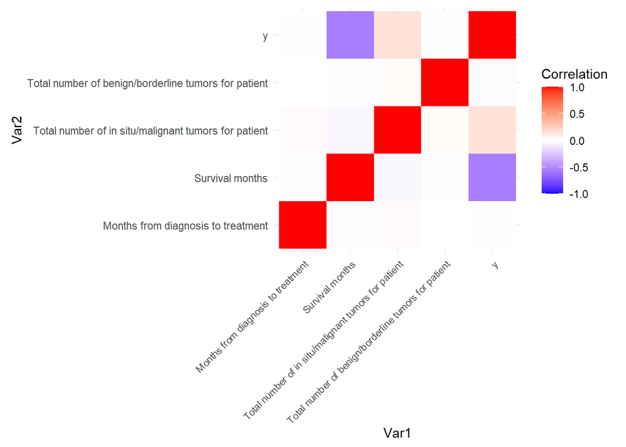

```r
library(reshape2)  # For melt function

# Melt correlation matrix
correlation_melted <- melt(correlation_table)

# Plot heatmap
ggplot(correlation_melted, aes(Var1, Var2, fill = value)) +
  geom_tile() +
  scale_fill_gradient2(low = "blue", high = "red", mid = "white",
                       midpoint = 0, limit = c(-1, 1), space = "Lab",
                       name = "Correlation") +
  theme_minimal() +
  theme(axis.text.x = element_text(angle = 45, vjust = 1,
                                    size = 8, hjust = 1)) +
  coord_fixed()
```

```r
# Calculate Cramér's V for association between "COD" and categorical columns
cramer_v <- apply(categorical_data, 2, function(x) {
  table_data <- table(x, BREAST_DF_surv_clean$COD)
  assoc(table_data, method = "cramers")
})
```

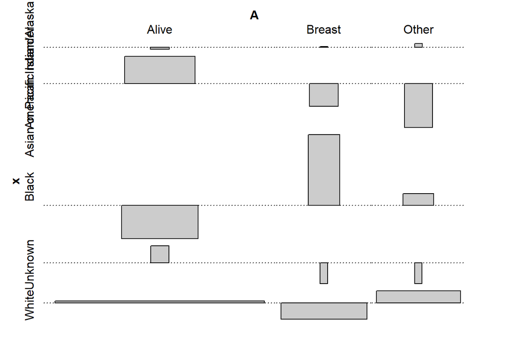

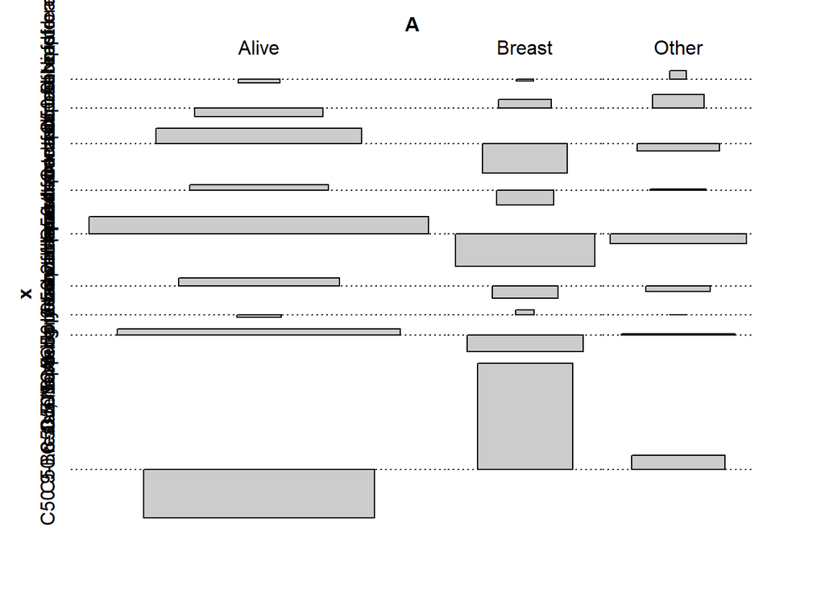

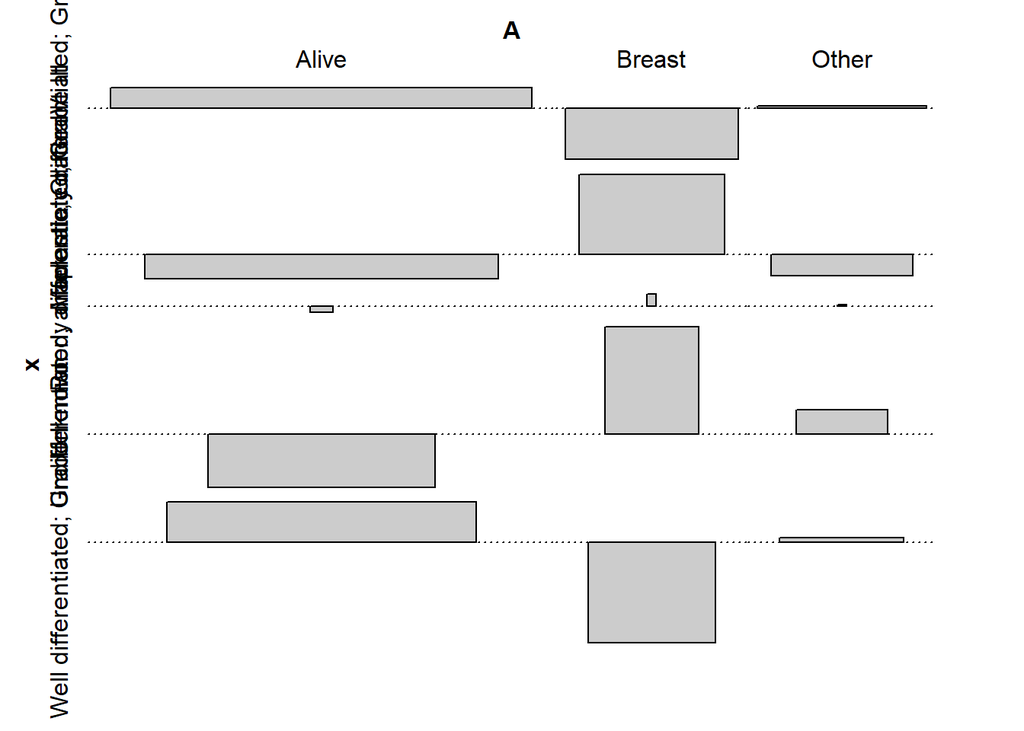

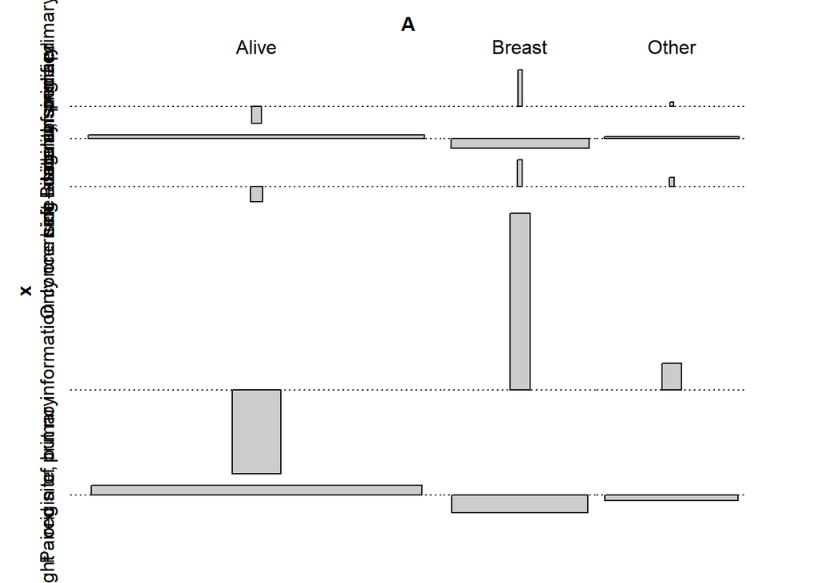

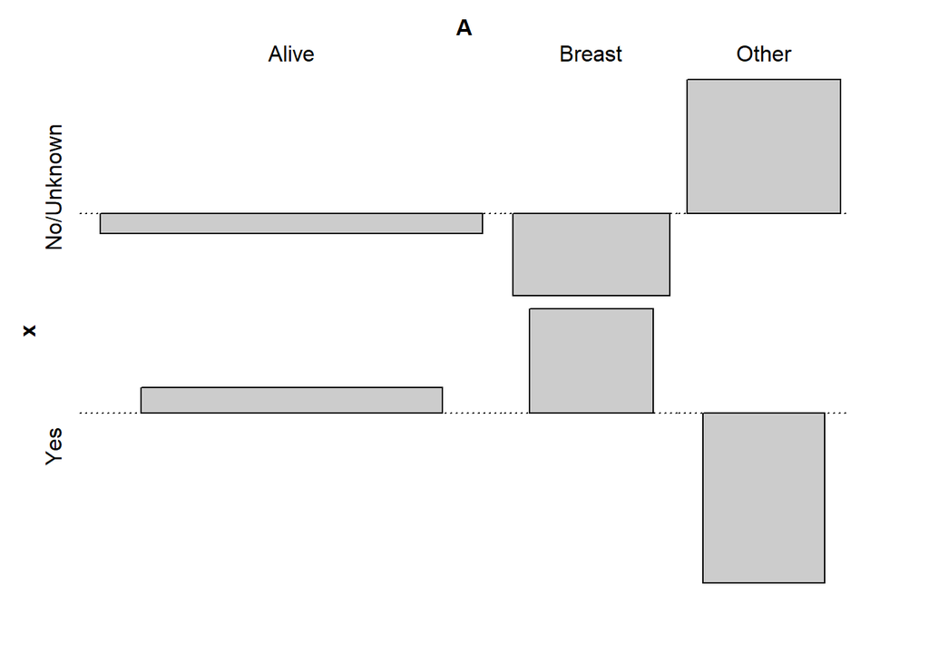

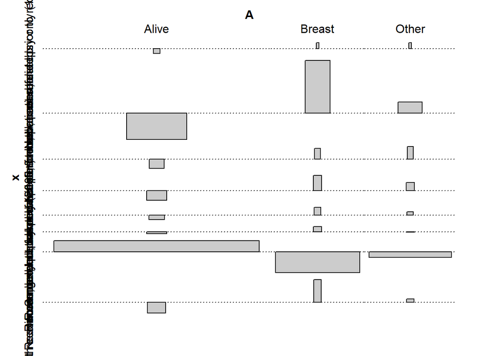

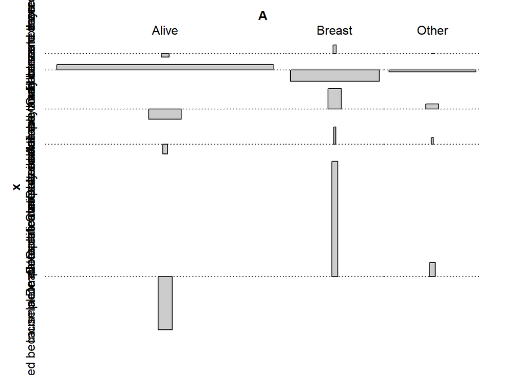

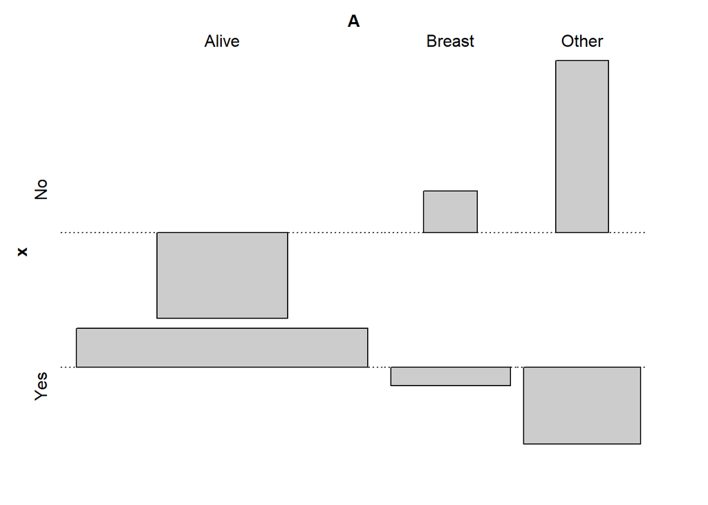

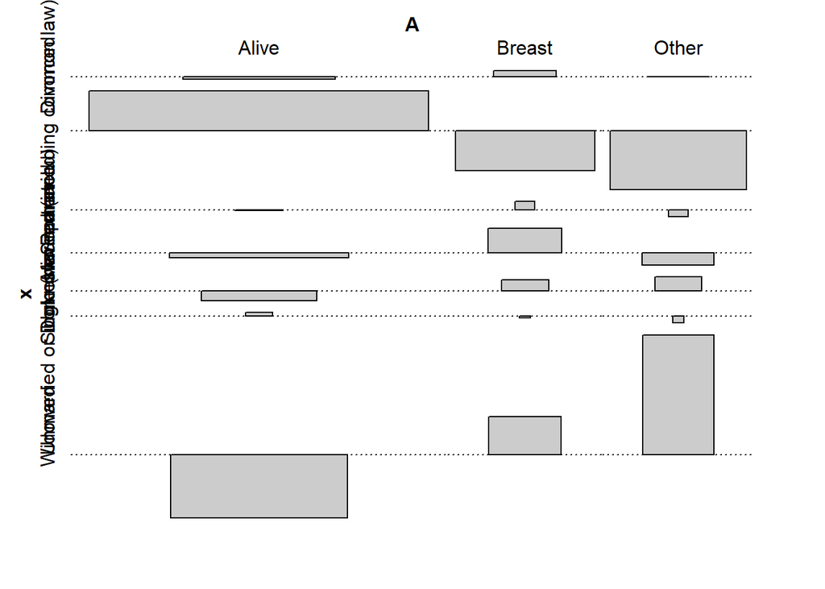

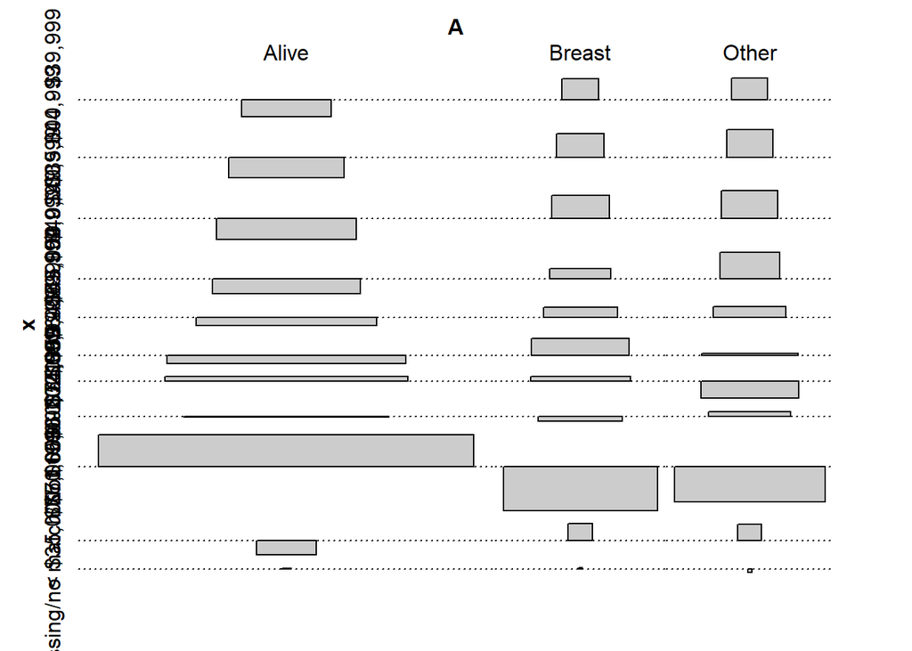

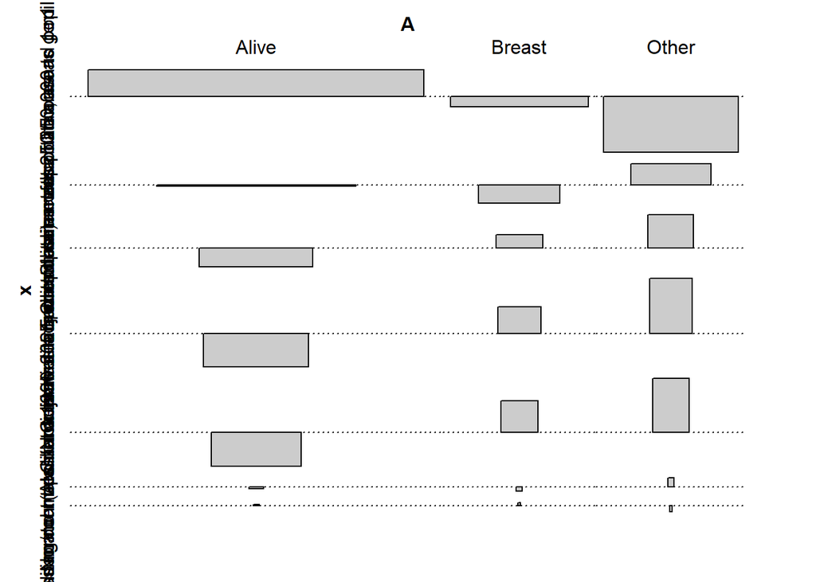

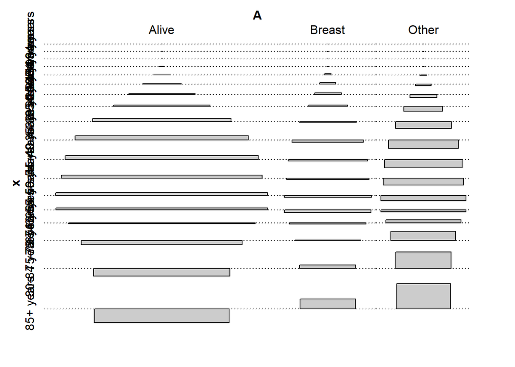

[2 more figures not shown]

```r
# Print Cramér's V for association with categorical columns
#print(cramer_v)

# Insert a line break or comment to separate the code blocks
cat("\n")
```

```r
# Initialize an empty data frame
cramer_v_df <- data.frame(Variable = character(), Value = numeric(), row.names = NULL)

# Iterate over each variable and its associated Cramér's V value
for (var_name in names(cramer_v)) {
  # Extract Cramér's V value for the current variable
  cramer_v_value <- cramer_v[[var_name]]

  # Append a row to the data frame with the variable name and its Cramér's V value
  cramer_v_df <- rbind(cramer_v_df, data.frame(Variable = var_name, Value = cramer_v_value))
}

# Print as a table
kable(cramer_v_df, caption = "Cramer's V for Association with COD")
```

| Variable | Value.x | Value.A | Value.Freq |
| --- | --- | --- | --- |
| Race recode (W, B, AI, API) | American Indian/Alaska Native | Alive | 1416 |
| Race recode (W, B, AI, API) | Asian or Pacific Islander | Alive | 22312 |
| Race recode (W, B, AI, API) | Black | Alive | 21523 |
| Race recode (W, B, AI, API) | Unknown | Alive | 1681 |
| Race recode (W, B, AI, API) | White | Alive | 181289 |
| Race recode (W, B, AI, API) | American Indian/Alaska Native | Breast | 252 |
| Race recode (W, B, AI, API) | Asian or Pacific Islander | Breast | 2749 |
| Race recode (W, B, AI, API) | Black | Breast | 6369 |
| Race recode (W, B, AI, API) | Unknown | Breast | 70 |
| Race recode (W, B, AI, API) | White | Breast | 29032 |
| Race recode (W, B, AI, API) | American Indian/Alaska Native | Other | 265 |
| Race recode (W, B, AI, API) | Asian or Pacific Islander | Other | 2000 |
| Race recode (W, B, AI, API) | Black | Other | 4273 |
| Race recode (W, B, AI, API) | Unknown | Other | 63 |
| Race recode (W, B, AI, API) | White | Other | 30263 |
| Primary Site - labeled | C50.0-Nipple | Alive | 1033 |
| Primary Site - labeled | C50.1-Central portion of breast | Alive | 9851 |
| Primary Site - labeled | C50.2-Upper-inner quadrant of breast | Alive | 28945 |
| Primary Site - labeled | C50.3-Lower-inner quadrant of breast | Alive | 12769 |
| Primary Site - labeled | C50.4-Upper-outer quadrant of breast | Alive | 77369 |
| Primary Site - labeled | C50.5-Lower-outer quadrant of breast | Alive | 17218 |
| Primary Site - labeled | C50.6-Axillary tail of breast | Alive | 1205 |
| Primary Site - labeled | C50.8-Overlapping lesion of breast | Alive | 52392 |
| Primary Site - labeled | C50.9-Breast, NOS | Alive | 27439 |
| Primary Site - labeled | C50.0-Nipple | Breast | 173 |
| Primary Site - labeled | C50.1-Central portion of breast | Breast | 2043 |
| Primary Site - labeled | C50.2-Upper-inner quadrant of breast | Breast | 3058 |
| Primary Site - labeled | C50.3-Lower-inner quadrant of breast | Breast | 1572 |
| Primary Site - labeled | C50.4-Upper-outer quadrant of breast | Breast | 9710 |
| Primary Site - labeled | C50.5-Lower-outer quadrant of breast | Breast | 2287 |

[output cut: 237 more lines]

```r
# Melt Cramér's V results
cramer_v_melted <- melt(cramer_v_df, id.vars = "Variable", variable.name = "Var1", value.name = "value")
```

[figure not shown]

```r
# Plot as a bar graph
ggplot(cramer_v_melted, aes(x = Variable, y = value, fill = Var1)) +
  geom_bar(stat = "identity") +
  theme_minimal() +
  theme(axis.text.x = element_text(angle = 45, vjust = 1, hjust = 1),
        axis.text.y = element_text(angle = 45, hjust = 1, vjust = 1)) + # Rotate y-axis labels by 45 degrees
  scale_y_discrete(labels = function(x) str_wrap(x, width = 10)) + # Wrap labels with a width of 10 characters
  labs(x = "Variable", y = "Cramer's V", fill = "Variable") +
  ggtitle("Cramer's V for Association with COD")
```

```r
#Since there are many factors and categorical variables I need to encode them.
#the followign code can deal with encoding
#Find the index of the column named "COD"
# Step 1: Find the index of the column named "COD"
cod_column_index <- which(names(BREAST_DF_surv_clean) == "COD")

# Step 2: Exclude "COD" column from model matrix
encoded_data <- model.matrix(~ . - 1, data = BREAST_DF_surv_clean[, -cod_column_index])

# Step 3: Select encoded variables and target variable
encoded_data <- cbind(encoded_data, COD = BREAST_DF_surv_clean$COD)
# Step 4: Calculate correlation matrix
correlation_matrix <- cor(encoded_data)
```

[figure not shown]

```r
# Step 5: Display summary statistics of the correlation matrix
summary_table <- summary(correlation_matrix)
summary_table_kable <- kable(summary_table)

# Step 6: Plot correlation matrix as a heatmap
library(corrplot)
corrplot(correlation_matrix, method = "color", tl.cex = 0.15, title = "Correlation Matrix")
```